# Exploratory Subgroup Identification with ForestSearch

German Breast Cancer Study Group (GBSG) Analysis

Author

Larry F. León

Published

April 21, 2026

# 1 Introduction

This vignette demonstrates the **ForestSearch** methodology for exploratory subgroup identification in survival analysis, as described in León et al. (2024) *Statistics in Medicine*.

## 1.1 Motivation

In clinical trials, particularly oncology, subgroup analyses are essential for:

- Evaluating treatment effect consistency across patient populations
- Identifying subgroups where treatment may be detrimental (harm)
- Characterizing subgroups with enhanced benefit
- Informing regulatory decisions and clinical practice

While prespecified subgroups provide stronger evidence, important subgroups based on patient characteristics may not be anticipated. ForestSearch provides a principled approach to **exploratory** subgroup identification with proper statistical inference.

## 1.2 Methodology Overview

ForestSearch identifies subgroups through:

1. **Candidate factor selection**: Using LASSO and/or Generalized Random Forests (GRF)
2. **Exhaustive subgroup search**: Evaluating all combinations up to `maxk` factors
3. **Consistency-based selection**: Applying splitting consistency criteria
4. **Bootstrap bias correction**: Adjusting for selection-induced optimism
5. **Cross-validation**: Assessing algorithm stability

The key innovation is the **splitting consistency criterion**: a subgroup is considered “consistent with harm” if, when randomly split 50/50 many times, both halves consistently show hazard ratios ≥ 1.0 (where 1.0 represents a meaningful “harm threshold”). An appendix (Section 10) directly calibrates the procedure-level false-positive rate (FPR) at the operational thresholds used in the main analysis.

## 1.3 Executive Overview

**Goal.** This analysis applies ForestSearch to the GBSG breast cancer trial (N = 686) to ask whether there exists a sizeable subgroup of patients for whom hormonal therapy may *not* be beneficial — or may even be detrimental. The analysis is run with `sg_focus = "maxSG"`, which targets the **largest** subgroup satisfying the harm criterion rather than the smallest or the one with the most extreme hazard ratio. This framing is intentional: from a risk-management standpoint, the more actionable question is “how many patients in the trial population could reasonably be recommended *against* this therapy?” rather than “what is the worst-affected subgroup we can find?”. A larger identified subgroup, if genuine, translates into a larger population for whom alternative therapies should be considered.

**Key findings.** At the León (2024) operational thresholds (c₁ = 1.25 screening, c₂ = 1.00 consistency) with `pconsistency.threshold = 0.90` and `stop_threshold = 0.95`, ForestSearch identifies **ER-negative patients (estrogen receptor status ≤ 0)** as the largest subgroup passing the harm criterion — 82 patients, 12% of the ITT population. The identified subgroup shows an estimated hazard ratio of 1.95 (95% CI: 1.04, 3.67) against the therapy, while the complement (604 patients, 88%) shows a clear benefit of 0.61 (0.47, 0.80). Overall ITT is 0.69 (0.54, 0.89). The finding is biologically plausible: tamoxifen is a selective estrogen receptor modulator with limited efficacy in ER-negative disease, and meta-analyses and clinical guidelines already recommend tamoxifen primarily for ER-positive tumors.

# 2 Setup

## 2.1 Packages

```r
library(forestsearch)
library(survival)
library(data.table)
library(ggplot2)
library(gt)
library(grf)
library(policytree)
library(foreach)
library(doFuture)
library(future)

# Optional
library(patchwork)
library(weightedsurv)

theme_set(theme_minimal(base_size = 12))
```

# 3 Data: German Breast Cancer Study Group

## 3.1 Study Background

The GBSG trial evaluated hormonal treatment (tamoxifen) versus chemotherapy in node-positive breast cancer patients. Key characteristics:

- **Sample size**: N = 686
- **Outcome**: Recurrence-free survival time
- **Censoring rate**: ~56%
- **Treatment**: Hormonal therapy (tamoxifen) vs. chemotherapy

## 3.2 Data Preparation

```r
# Load GBSG data (included in forestsearch package)
df.analysis <- gbsg

# Prepare analysis variables
df.analysis <- within(df.analysis, {
  id <- seq_len(nrow(df.analysis))
  time_months <- rfstime / 30.4375
  grade3 <- ifelse(grade == "3", 1, 0)
  treat <- hormon
})

# Define variable roles
confounders.name <- c("age", "meno", "size", "grade3", "nodes", "pgr", "er")
outcome.name <- "time_months"
event.name   <- "status"
id.name      <- "id"
treat.name   <- "hormon"

cat("Sample size:", nrow(df.analysis), "\n")
```

```
#> Sample size: 686
```

```r
cat("Events:", sum(df.analysis[[event.name]]),
    sprintf("(%.1f%%)\n", 100 * mean(df.analysis[[event.name]])))
```

```
#> Events: 299 (43.6%)
```

```r
cat("Baseline factors:", paste(confounders.name, collapse = ", "), "\n")
```

```
#> Baseline factors: age, meno, size, grade3, nodes, pgr, er
```

## 3.3 Baseline Characteristics

```r
create_summary_table(
  data             = df.analysis,
  treat_var        = treat.name,
  table_title      = "GBSG Baseline Characteristics by Treatment Arm",
  vars_continuous  = c("age", "nodes", "size", "er", "pgr"),
  vars_categorical = c("grade", "meno"),
  font_size        = 12
)
```

GBSG Baseline Characteristics by Treatment Arm

| Characteristic |  | Control (n=440) | Treatment (n=246) | P-value<sup>1</sup> | SMD<sup>2</sup> |
| --- | --- | --- | --- | --- | --- |
| age | Mean (SD) | 51.1 (10.0) | 56.6 (9.4) | <0.001 | 0.57 |
| nodes | Mean (SD) | 4.9 (5.6) | 5.1 (5.3) | 0.665 | 0.03 |
| size | Mean (SD) | 29.6 (14.4) | 28.8 (14.1) | 0.470 | 0.06 |
| er | Mean (SD) | 79.7 (124.2) | 125.8 (191.1) | <0.001 | 0.30 |
| pgr | Mean (SD) | 102.0 (170.0) | 124.3 (249.7) | 0.213 | 0.11 |
| grade |  |  |  | 0.273 | 0.06 |
|  | 1 | 48 (10.9%) | 33 (13.4%) |  |  |
|  | 2 | 281 (63.9%) | 163 (66.3%) |  |  |
|  | 3 | 111 (25.2%) | 50 (20.3%) |  |  |
| meno |  | 209 (47.5%) | 187 (76.0%) | <0.001 | 0.61 |

<sup>1</sup> P-values: t-test for continuous, chi-square/Fisher's exact for categorical/binary variables  
<sup>2</sup> SMD = Standardized mean difference (Cohen's d for continuous, Cramer's V for categorical)

## 3.4 Kaplan-Meier Analysis (ITT Population)

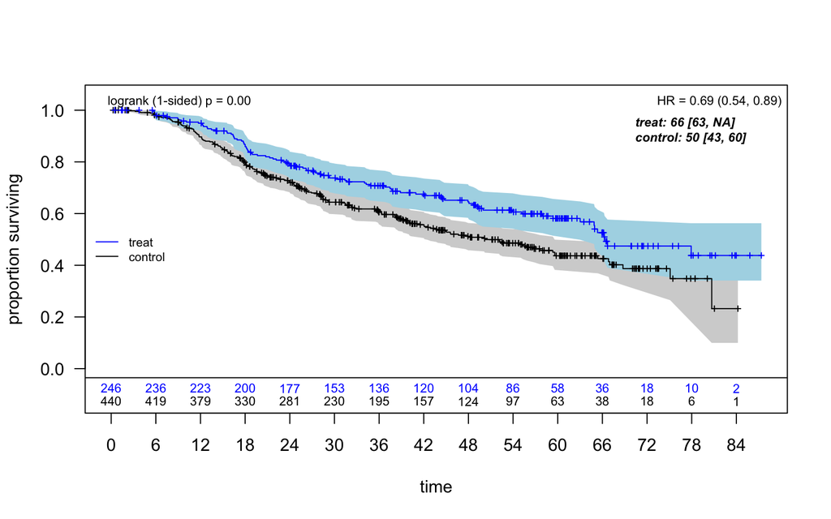

ITT Kaplan-Meier curves with 95% CI and log-rank test.

```r
dfcount <- df_counting(
  df         = df.analysis,
  by.risk    = 6,
  tte.name   = outcome.name,
  event.name = event.name,
  treat.name = treat.name
)

plot_weighted_km(
  dfcount,
  conf.int      = TRUE,
  show.logrank  = TRUE,
  ymax          = 1.05,
  xmed.fraction = 0.775,
  ymed.offset   = 0.125
)
```

The ITT Cox hazard ratio estimate is approximately 0.69 (95% CI: 0.54, 0.89), suggesting an overall benefit for hormonal therapy.

# 4 Preliminary Analysis: Generalized Random Forests

Before running ForestSearch, we use GRF to explore potential treatment effect heterogeneity and identify candidate factors.

```r
t0 <- proc.time()

grf_est <- grf.subg.harm.survival(
  data             = df.analysis,
  confounders.name = confounders.name,
  outcome.name     = outcome.name,
  event.name       = event.name,
  id.name          = id.name,
  treat.name       = treat.name,
  maxdepth         = 2,
  n.min            = n_min_val,
  dmin.grf         = 4,
  frac.tau         = 0.8,
  details          = TRUE,
  return_selected_cuts_only = FALSE
)
```

```
#> tau, maxdepth = 62.34415 2
#>    leaf.node control.mean control.size control.se depth
#> 1          2         7.17        82.00       4.76     1
#> 2          3        -6.41       604.00       1.59     1
#> 11         4       -12.16       112.00       4.04     2
#> 21         5         5.82       177.00       2.82     2
#> 4          7        -9.28       356.00       2.01     2
#>
#> Selected subgroup:
#>   leaf.node control.mean control.size control.se depth
#> 1         2         7.17        82.00       4.76     1
#>
#> GRF subgroup found
#> Terminating node at max.diff (sg.harm.id):
#> [1] "er <= 0"
#>
#> All splits (from all trees):
#> [1] "er <= 0"   "age <= 50" "age <= 43"
```

```r
timings$grf <- (proc.time() - t0)["elapsed"]
```

```r
oldpar <- par(mfrow = c(1, 2))
plot(grf_est$tree1, leaf.labels = c("Control", "Treat"), main = "Depth 1")
```

[interactive chart not shown]

GRF policy trees. leaf1 = recommend control; leaf2 = recommend treatment.

```r
plot(grf_est$tree2, leaf.labels = c("Control", "Treat"), main = "Depth 2")
```

[interactive chart not shown]

GRF policy trees. leaf1 = recommend control; leaf2 = recommend treatment.

```r
par(oldpar)
```

GRF identifies estrogen receptor status (ER) as a key factor, with ER ≤ 0 suggesting potential harm from hormonal therapy.

# 5 ForestSearch Analysis

## 5.1 Running ForestSearch

ForestSearch performs an exhaustive search over candidate subgroup combinations with up to `maxk` factors. Key parameters:

| Parameter | Value | Description |
| --- | --- | --- |
| `hr.threshold` | 1.25 | Minimum HR for consistency evaluation |
| `hr.consistency` | 1 | Minimum consistency rate for candidates |
| `pconsistency.threshold` | 0.9 | Required consistency for selection |
| `maxk` | 2 | Maximum factors in subgroup definition |
| `n.min` | 60 | Minimum subgroup sample size |
| `d0.min`, `d1.min` | 10 | Minimum events per treatment arm |

```
#> GRF subgroup: age <= 43
#> GRF cuts identified: 3
#>   Cuts: age <= 50, age <= 43, er <= 0
#> Cox-LASSO selected: 4 of 7 candidate factors
#>   Omitted: age, meno, er
#> Candidate factors: 16
#>  [1] "age <= 50"    "age <= 43"    "er <= 0"      "size <= 29.3" "size <= 25"
#>  [6] "size <= 20"   "size <= 35"   "nodes <= 5"   "nodes <= 3"   "nodes <= 1"
#> [11] "nodes <= 7"   "pgr <= 110"   "pgr <= 32.5"  "pgr <= 7"     "pgr <= 131.8"
#> [16] "grade3"
#> Number of possible configurations (<= maxk): maxk = 2 , # combinations = 528
#> Per-arm events criteria: control >= 10, treatment >= 10
#> Sample size criteria: n >= 60
#> Subgroup search completed in 0.01 minutes
#>
#> --- Filtering Summary ---
#>   Combinations evaluated: 528
#>   Passed variance check: 493
#>   Passed prevalence (>= 0.025 ): 493
#>   Passed redundancy check: 472
#>   Passed events counts (d0>= 10, d1>= 10): 346
#>   Passed sample size (n>= 60 ): 337
#>   Cox model fit successfully: 337
#>   Passed effect threshold (effect >= 1.2500): 13
#> -------------------------
#>
#> Found 13 subgroup candidate(s)
#> # of candidate subgroups (meeting all criteria) = 13
#> # of unique initial candidates: 13
#> # Restricting to top stop_Kgroups = 10
#> # of candidates to evaluate: 10
#> # Early stop threshold: 0.95
#>
#> ================================================================================
#> TOP 10 CANDIDATE SUBGROUPS FOR CONSISTENCY EVALUATION
#> Sorted by: maxSG
#> ================================================================================
#>
#> Rank   HR        N       Events  K    Subgroup Definition
#> --------------------------------------------------------------------------------
#> 1      1.285     203     92      2    {age <= 50} & {pgr <= 110}
#> 2      1.530     177     55      2    {age <= 50} & !{age <= 43}
#> 3      1.397     142     72      2    {age <= 50} & {pgr <= 32.5}
#> 4      1.951     82      45      1    {er <= 0}
#> 5      2.222     75      41      2    {er <= 0} & {pgr <= 32.5}
#> 6      1.710     72      39      2    {grade3} & {pgr <= 7}
#> 7      1.707     71      36      2    {age <= 50} & {pgr <= 7}
#> 8      1.319     71      29      2    !{size <= 35} & {nodes <= 5}
#> 9      2.164     68      38      2    {er <= 0} & !{age <= 43}
#> 10     1.992     64      34      2    {er <= 0} & {pgr <= 7}
#> --------------------------------------------------------------------------------
```

```
#> Parallel config: workers = 12 , batch_size = 2
#> Batch 1 / 5 : candidates 1 - 2
#> Batch 2 / 5 : candidates 3 - 4
#> Batch 3 / 5 : candidates 5 - 6
#>
#> ==================================================
#> EARLY STOP TRIGGERED (batch 3 )
#>   Candidate: 5 of 10
#>   Pcons: 0.97 >= 0.95
#> ==================================================
#>
#> Evaluated 6 of 10 candidates (early stop)
#> 2 subgroups passed consistency threshold
```

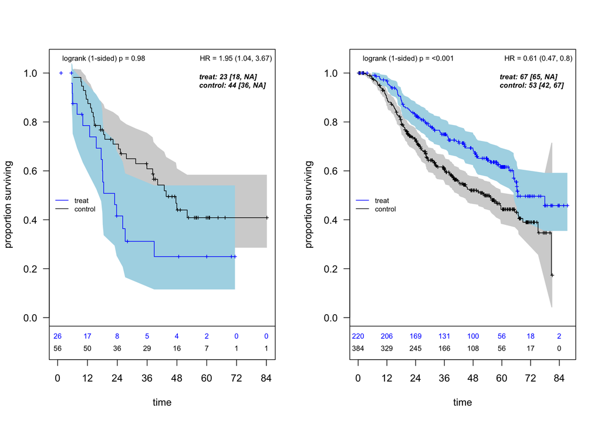

```
#> *** Subgroup found: {er <= 0}
#> % consistency criteria met= 0.94
#> SG focus = maxSG
#> Seconds and minutes forestsearch overall = 3.499 0.0583
#> Consistency algorithm used: twostage
#> Subgroup identified: {er <= 0}
```

```r
t0 <- proc.time()

fs <- forestsearch(
  df.analysis,
  confounders.name = confounders.name,
  outcome.name     = outcome.name,
  treat.name       = treat.name,
  event.name       = event.name,
  id.name          = id.name,
  # Threshold parameters (per León et al. 2024)
  hr.threshold           = c1_paper,
  hr.consistency         = c2_paper,
  pconsistency.threshold = pcons_val,
  stop_threshold         = stop_thresh_val,
  # Search configuration
  sg_focus             = "maxSG",
  max_subgroups_search = max_sgs_search_val,
  use_twostage         = TRUE,
  # Factor selection
  use_grf                   = TRUE,
  dmin.grf             = 0,
  frac.tau             = 1.0,
  return_selected_cuts_only = TRUE,
  use_lasso                 = TRUE,
  cut_type                  = "default",
  # Subgroup constraints
  maxk   = maxk_val,
  n.min  = n_min_val,
  d0.min = d0_min_val,
  d1.min = d1_min_val,
  # Consistency evaluation
  fs.splits = fs_splits_val,
  # Parallel processing
  parallel_args = list(
    plan         = "multisession",
    workers      = n_workers,
    show_message = TRUE
  ),
  # Output
  showten_subgroups = TRUE,
  details           = TRUE,
  plot.sg           = TRUE
)
```

```r
plan("sequential")
timings$forestsearch <- (proc.time() - t0)["elapsed"]

cat("\nForestSearch completed in",
    round(timings$forestsearch, 1), "seconds\n")
```

```
#>
#> ForestSearch completed in 3.5 seconds
```

## 5.2 ForestSearch Results

### 5.2.1 Identified Subgroups

```r
res_tabs <- sg_tables(fs, ndecimals = 3, which_df = "est")
res_tabs$sg10_out
```

**Identified Subgroups**

Two-factor subgroups (maxk=2)

| Factor 1 | Factor 2 | N | Events | E<sub>1</sub> | HR | P<sub>cons</sub> |
| --- | --- | --- | --- | --- | --- | --- |
| {er <= 0} |  | 82 | 45 | 16 | 1.951 | 0.940 |
| {er <= 0} | {pgr <= 32.5} | 75 | 41 | 16 | 2.222 | 0.970 |

**Search Configuration:** Single-factor candidates (L) = 32; Maximum combinations evaluated = 528; Search depth (maxk) = 2  
**Search Results:** Candidate subgroups found = 13; Maximum HR estimate = 2.54  
**Note:** E<sub>1</sub> = events in treatment arm; P<sub>cons</sub> = consistency proportion

### 5.2.2 Treatment Effect Estimates

```r
res_tabs$tab_estimates
```

**Treatment Effect Estimates**

Training data estimates

| Subgroup | n | n1 | events | m1 | m0 | RMST | HR (95% CI) |
| --- | --- | --- | --- | --- | --- | --- | --- |
| ITT | 686 (100.0%) | 246 (35.9%) | 299 (43.6%) | 66.3 | 50.2 | 7.8 | 0.69 (0.54, 0.89) |
| Questionable<sup>1</sup> | 82 (12.0%) | 26 (31.7%) | 45 (54.9%) | 22.9 | 43.7 | -14 | 1.95 (1.04, 3.67) |
| Recommend | 604 (88.0%) | 220 (36.4%) | 254 (42.1%) | 66.7 | 52.6 | 9.3 | 0.61 (0.47, 0.80) |

<sup>1</sup> **Identified subgroup** : {er <= 0}

### 5.2.3 Identified Subgroup Definition

```r
cat("Identified subgroup (H):", paste(fs$sg.harm, collapse = " & "), "\n")
```

```
#> Identified subgroup (H): {er <= 0}
```

```r
cat("Subgroup size:", sum(fs$df.est$treat.recommend == 0),
    sprintf("(%.1f%% of ITT)\n",
            100 * mean(fs$df.est$treat.recommend == 0)))
```

```
#> Subgroup size: 82 (12.0% of ITT)
```

ForestSearch identifies **Estrogen ≤ 0** (ER-negative) as the subgroup with potential harm. This is biologically plausible: tamoxifen is a selective estrogen receptor modulator with limited efficacy in ER-negative tumors.

### 5.2.4 Agreement with GRF

ForestSearch and GRF identify subgroups by different mechanisms — FS via exhaustive search with consistency filtering, GRF via causal survival forests plus policy trees — so agreement on subject-level membership provides an informal robustness check. `compare_fs_subgroups()` produces a publication-ready cross-tabulation plus Cohen’s kappa.

```r
sg_compare <- compare_fs_subgroups(
  fs1               = fs,
  fs2               = grf_est,
  label1            = "ForestSearch",
  label2            = "GRF Standalone",
  id.name           = id.name,
  subgroup_notation = "harm",
  title             = "FS vs GRF: Subgroup Membership Concordance",
  subtitle          = "GBSG observed data (Cox, harm search)",
  font_size         = 13
)
sg_compare$table
```

**FS vs GRF: Subgroup Membership Concordance**

GBSG observed data (Cox, harm search)

| ForestSearch | GRF Standalone H (Questionable) | GRF Standalone Hᶜ (Recommend) | Total |  |
| --- | --- | --- | --- | --- |
| H (Questionable) | 82 | 0 |  | 82 |
| Hᶜ (Recommend) | 0 | 604 | 604 |  |
| Total | 82 | 604 | 686 |  |

**Agreement:** 686 / 686 (100.0%) **Cohen’s κ:** 1.000 **ForestSearch H:** {er <= 0} **GRF Standalone H:** er <= 0

```r
cat("Concordance statistics:\n")
```

```
#> Concordance statistics:
```

```r
cat(sprintf("  Agreement:       %.1f%%\n",
    100 * sg_compare$concordance$agreement))
```

```
#>   Agreement:       100.0%
```

```r
cat(sprintf("  Cohen's kappa:   %.3f\n",
    sg_compare$concordance$kappa))
```

```
#>   Cohen's kappa:   1.000
```

```r
cat(sprintf("  Concordant:      %d / Discordant: %d / Total: %d\n",
    sg_compare$concordance$n_agree,
    sg_compare$concordance$n_disagree,
    sg_compare$concordance$n_total))
```

```
#>   Concordant:      686 / Discordant: 0 / Total: 686
```

# 6 Bootstrap Bias Correction

## 6.1 Rationale

Cox model estimates from identified subgroups are **upwardly biased** due to the selection process (subgroups are selected *because* they show extreme effects). Bootstrap bias correction addresses this by:

1. Resampling with replacement
2. Re-running the entire ForestSearch algorithm
3. Computing bias terms from bootstrap vs. observed estimates
4. Applying infinitesimal jackknife variance estimation

## 6.2 Running Bootstrap Analysis

```r
.boot_key <- list(
  sg_harm        = fs$sg.harm,
  sg_size        = sum(fs$df.est$treat.recommend == 0),
  c1             = c1_paper,
  c2             = c2_paper,
  pcons          = pcons_val,
  stop_thresh    = stop_thresh_val,
  fs_splits      = fs_splits_val,
  n_min          = n_min_val,
  d0_min         = d0_min_val,
  d1_min         = d1_min_val,
  maxk           = maxk_val,
  NB_boot        = NB_boot,
  seed_main      = 8316951L       # ForestSearch's internal seed
)

.boot_cached <- .cache_compute(
  cache_file = "bootstrap_main.rds",
  key        = .boot_key,
  label      = sprintf("bootstrap (%d iterations)", NB_boot),
  compute    = function() {
    t0 <- proc.time()[3]
    res <- forestsearch_bootstrap_dofuture(
      fs.est        = fs,
      nb_boots      = NB_boot,
      show_three    = FALSE,
      details       = FALSE,
      parallel_args = list(
        plan         = "multisession",
        workers      = n_workers,
        show_message = TRUE
      )
    )
    plan("sequential")
    list(result = res, elapsed = proc.time()[3] - t0)
  }
)

fs_bc              <- .boot_cached$result
timings$bootstrap  <- .boot_cached$elapsed
cat("\nBootstrap completed in",
    round(timings$bootstrap / 60, 1), "minutes (cache-aware)\n")
```

```
#>
#> Bootstrap completed in 1.5 minutes (cache-aware)
```

## 6.3 Bootstrap Summary and Diagnostics

```r
summaries <- summarize_bootstrap_results(
  sgharm       = fs$sg.harm,
  boot_results = fs_bc,
  create_plots = TRUE,
  est.scale    = "hr"
)
```

```
#>
#> ===============================================================
#>            BOOTSTRAP ANALYSIS SUMMARY
#> ===============================================================
#>
#> IDENTIFIED SUBGROUP:
#> -------------------------------------------------------------
#>   H: {er <= 0}
#>
#> BOOTSTRAP SUCCESS METRICS:
#> -------------------------------------------------------------
#>   Total iterations:              200
#>   Successful subgroup ID:        169 (84.5%)
#>   Failed to find subgroup:       31 (15.5%)
#>
#> TIMING ANALYSIS:
#> -------------------------------------------------------------
#> Overall:
#>   Total bootstrap time:          1.45 minutes (0.02 hours)
#>   Average per iteration:         0.01 min (0.4 sec)
#>   Projected for 1000 boots:      7.25 min (0.12 hrs)
```

```r
summaries$table
```

**Treatment Effect by Subgroup**

Bootstrap bias-corrected estimates (200 iterations)

| Subgroup | Sample Size N | Sample Size N<sub>T</sub> | Sample Size Events | Survival Med<sub>T</sub> | Survival Med<sub>C</sub> | Survival RMST<sub>d</sub> | Treatment Effect HR (95% CI)†<sup>1</sup> | Treatment Effect HR‡ (95% CI)<sup>2</sup> |
| --- | --- | --- | --- | --- | --- | --- | --- | --- |
| Qstnbl<sup>3</sup> | 82 (12.0%) | 26 (31.7%) | 45 (54.9%) | 22.9 | 43.7 | -14 | 1.95 (1.04, 3.67) | 1.63 (0.86,3.11) |
| Recmnd | 604 (88.0%) | 220 (36.4%) | 254 (42.1%) | 66.7 | 52.6 | 9.3 | 0.61 (0.47, 0.80) | 0.66 (0.51,0.85) |

<sup>1</sup> **Unadjusted HR**: Standard Cox regression hazard ratio with robust standard errors  
<sup>2</sup> **Bias-corrected HR**: Bootstrap-adjusted estimate using infinitesimal jackknife method (200 iterations). Corrects for optimism in subgroup selection.  
<sup>3</sup> **Identified subgroup**: {er <= 0}  
*Note*: Med = Median survival time (months). RMST<sub>d</sub> = Restricted mean survival time difference. Subgroup identified in 84.5% of bootstrap samples.

## 6.4 Kaplan-Meier by Identified Subgroups

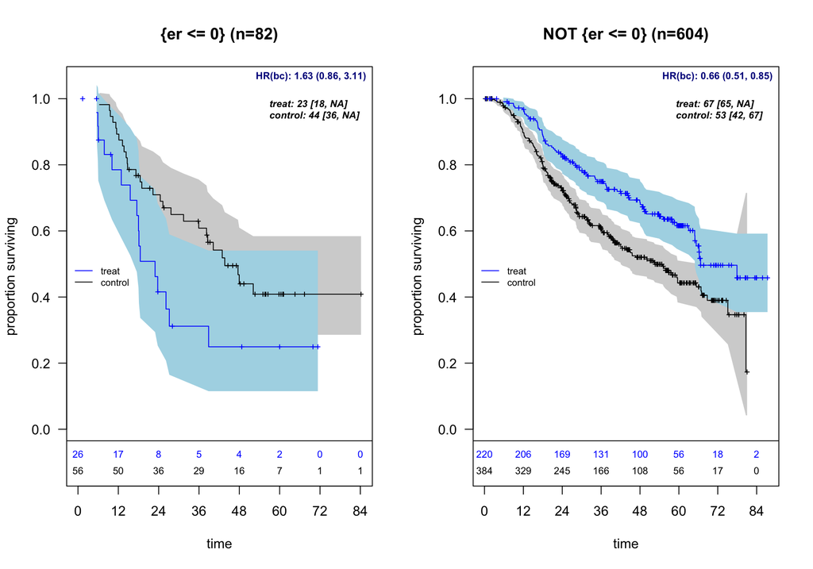

Kaplan-Meier survival curves by identified subgroup

```r
km_result <- plot_sg_weighted_km(
  fs.est         = fs,
  outcome.name   = "time_months",
  event.name     = "status",
  treat.name     = "hormon",
  show.logrank   = FALSE,
  conf.int       = TRUE,
  by.risk        = 12,
  show.cox       = FALSE,
  show.cox.bc    = TRUE,
  fs_bc          = fs_bc,
  hr_bc_position = "topright"
)
```

**Note**

**Note:** Identified subgroup: {er <= 0}. HR(bc) = bootstrap bias-corrected hazard ratio. Medians [95% CI] for arms are un-adjusted.

### 6.4.1 Event Count Summary

Low event counts can lead to unstable HR estimates.

```r
event_summary <- summarize_bootstrap_events(fs_bc, threshold = 15)
```

```
#>
#> === Bootstrap Event Count Summary ===
#> Total bootstrap iterations: 200
#> Event threshold: <15 events
#>
#> ORIGINAL Subgroup H on BOOTSTRAP samples:
#>   Control arm <15 events: 0 (0.0%)
#>   Treatment arm <15 events: 0 (0.0%)
#>   Either arm <15 events: 0 (0.0%)
#>
#> ORIGINAL Subgroup Hc on BOOTSTRAP samples:
#>   Control arm <15 events: 0 (0.0%)
#>   Treatment arm <15 events: 0 (0.0%)
#>   Either arm <15 events: 0 (0.0%)
#>
#> NEW Subgroups found: 169 (84.5%)
#>
#> NEW Subgroup H* on ORIGINAL data:
#>   Control arm <15 events: 10 (5.9% of successful)
#>   Treatment arm <15 events: 16 (9.5% of successful)
#>   Either arm <15 events: 20 (11.8% of successful)
#>
#> NEW Subgroup Hc* on ORIGINAL data:
#>   Control arm <15 events: 0 (0.0% of successful)
#>   Treatment arm <15 events: 3 (1.8% of successful)
#>   Either arm <15 events: 3 (1.8% of successful)
```

### 6.4.2 Bootstrap Diagnostics

```r
summaries$diagnostics_table_gt
```

**Bootstrap Diagnostics Summary**

Analysis of 200 bootstrap iterations

| Category | Metric | Value |
| --- | --- | --- |
| Success Rate | Total iterations | 200 |
|  | Successful | 169 (84.5%) |
|  | Failed | 31 (15.5%) |
|  | Success rating | Good |
| Subgroup H (Questionable) | Observed HR | 1.951 |
|  | Bias-corrected HR | 1.634 |
|  | Bootstrap CV (%) | 86.3% |
|  | N estimates | 169 |
| Subgroup Hc (Recommend) | Observed HR | 0.615 |
|  | Bias-corrected HR | 0.657 |
|  | Bootstrap CV (%) | 49.2% |
|  | N estimates | 169 |

### 6.4.3 Subgroup Agreement

How consistently does bootstrap identify the same subgroup?

```r
if (!is.null(summaries$subgroup_summary$original_agreement)) {
  summaries$subgroup_summary$original_agreement
}
```

```
#>                             Metric       Value
#>                             <char>      <char>
#> 1:      Total bootstrap iterations         200
#> 2:           Successful iterations         169
#> 3: Failed iterations (no subgroup)          31
#> 4:
#> 5:    Original subgroup definition   {er <= 0}
#> 6:       Exact match with original    6 (3.6%)
#> 7:         Different from original 163 (96.4%)
#> 8:   Partial match (shared factor)    9 (5.3%)
```

```r
if (!is.null(summaries$subgroup_summary$factor_presence)) {
  summaries$subgroup_summary$factor_presence
}
```

```
#>   Rank Factor Count   Percent
#> 6    1    pgr    99 58.579882
#> 1    2    age    90 53.254438
#> 7    3   size    59 34.911243
#> 2    4     er    38 22.485207
#> 5    5  nodes    15  8.875740
#> 3    6 grade3    14  8.284024
#> 4    7   meno     4  2.366864
```

### 6.4.4 Bootstrap Distributions

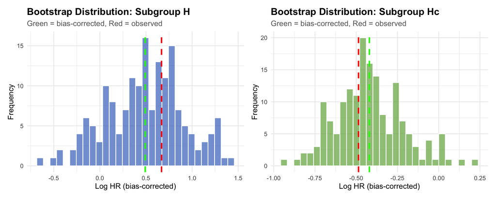

```r
if (!is.null(summaries$plots)) {
  summaries$plots$H_distribution + summaries$plots$Hc_distribution
}
```

# 7 Cross-Validation

Cross-validation assesses the **stability** of the ForestSearch algorithm. Two approaches are available.

## 7.1 K-Fold Cross-Validation

```r
.kfold_key <- list(
  sg_harm     = fs$sg.harm,
  sg_size     = sum(fs$df.est$treat.recommend == 0),
  c1          = c1_paper,
  c2          = c2_paper,
  pcons       = pcons_val,
  dmin.grf = 0,
  frac.tau = 1,
  stop_thresh = stop_thresh_val,
  fs_splits   = fs_splits_val,
  n_min       = n_min_val,
  d0_min      = d0_min_val,
  d1_min      = d1_min_val,
  maxk        = maxk_val,
  Ksims_cv    = Ksims_cv,
  Kfolds      = 10L
)

.kfold_cached <- .cache_compute(
  cache_file = "kfold_cv.rds",
  key        = .kfold_key,
  label      = sprintf("k-fold CV (%d sims × 10 folds)", Ksims_cv),
  compute    = function() {
    t0 <- proc.time()[3]
    res <- forestsearch_tenfold(
      fs.est        = fs,
      sims          = Ksims_cv,
      Kfolds        = 10,
      details       = FALSE,
      parallel_args = list(
        plan         = "multisession",
        workers      = n_workers,
        show_message = FALSE
      )
    )
    plan("sequential")
    list(result = res, elapsed = proc.time()[3] - t0)
  }
)

fs_kfold        <- .kfold_cached$result
timings$kfold   <- .kfold_cached$elapsed
metrics_tables  <- cv_metrics_tables(fs_kfold)
metrics_tables
```

**Cross-Validation Metrics**

Subgroup: Identified Subgroup

| Metric | Description | Value (%) |
| --- | --- | --- |
| Agreement |  |  |
| Sensitivity (H) | Agreement rate for subgroup H | 41.5 |
| Sensitivity (Hc) | Agreement rate for complement Hc | 95.0 |
| PPV (H) | Positive predictive value for H | 60.0 |
| PPV (Hc) | Positive predictive value for Hc | 92.2 |
| Subgroup Finding |  |  |
| Any Found | Any subgroup identified | 70.0 |
| Exact Match | Exact match on all factors | 40.0 |
| At Least 1 | At least one factor matches | 40.0 |
| Cov1 Any | First covariate found (any cut) | 40.0 |
| Cov2 Any | Second covariate found (any cut) | NA |
| Cov1 & Cov2 | Both covariates found | 0.0 |
| Cov1 Exact | First covariate exact match | 40.0 |
| Cov2 Exact | Second covariate exact match | NA |

Based on 5 simulation(s) with 10-fold CV. Values are medians shown as percentages.

## 7.2 Out-of-Bag (N-Fold) Cross-Validation

```r
.oob_kfolds <- round(nrow(df.analysis) / 100, 0)

.oob_key <- list(
  sg_harm     = fs$sg.harm,
  sg_size     = sum(fs$df.est$treat.recommend == 0),
  c1          = c1_paper,
  c2          = c2_paper,
  pcons       = pcons_val,
  stop_thresh = stop_thresh_val,
  fs_splits   = fs_splits_val,
  dmin.grf = 0,
  frac.tau = 1,
  n_min       = n_min_val,
  d0_min      = d0_min_val,
  d1_min      = d1_min_val,
  maxk        = maxk_val,
  n_sample    = nrow(df.analysis),
  Kfolds      = .oob_kfolds
)

.oob_cached <- .cache_compute(
  cache_file = "oob_cv.rds",
  key        = .oob_key,
  label      = sprintf("OOB CV (%d folds)", .oob_kfolds),
  compute    = function() {
    t0 <- proc.time()[3]
    res <- forestsearch_Kfold(
      fs.est        = fs,
      details       = FALSE,
      Kfolds        = .oob_kfolds,
      parallel_args = list(
        plan         = "multisession",
        workers      = n_workers,
        show_message = TRUE
      )
    )
    plan("sequential")
    list(result = res, elapsed = proc.time()[3] - t0)
  }
)

fs_OOB        <- .oob_cached$result
timings$oob   <- .oob_cached$elapsed

cv_out <- forestsearch_KfoldOut(
  res     = fs_OOB,
  details = FALSE,
  outall  = TRUE
)

tables <- cv_summary_tables(cv_out)
tables$combined_table
```

**Cross-Validation Summary**

ITT and Subgroup Estimates: Full Analysis (FA) vs K-fold (Kf)

| Analysis | Subgroup | n | n1 | m1 | m0 | RMST | Hazard ratio |
| --- | --- | --- | --- | --- | --- | --- | --- |
| Overall | ITT | 686 (100.0%) | 246 (35.9%) | 66.3 | 50.2 | 7.8 | 0.69 (0.54, 0.89) |
| FA_0 | Not recommend | 82 (12.0%) | 26 (31.7%) | 22.9 | 43.7 | -14 | 1.95 (1.04, 3.67) |
| KfA_0 | Not recommend | 55 (8.0%) | 13 (23.6%) | NA | 38.2 | 9.7 | 0.64 (0.25, 1.64) |
| FA_1 | Recommend | 604 (88.0%) | 220 (36.4%) | 66.7 | 52.6 | 9.3 | 0.61 (0.47, 0.80) |
| KfA_1 | Recommend | 631 (92.0%) | 233 (36.9%) | 66.3 | 52.2 | 6.8 | 0.71 (0.55, 0.91) |

FA = Full Analysis (original data), Kf = K-fold CV estimate

```r
tables$metrics_table
```

**Cross-Validation Metrics**

Agreement and subgroup finding rates (%)

| Metric | Value (%) |
| --- | --- |
| Agreement |  |
| Sensitivity (H) | 32.9 |
| Sensitivity (Hc) | 95.4 |
| PPV (H) | 49.1 |
| PPV (Hc) | 91.3 |
| Finding |  |
| Any Found | 57.1 |
| Exact Match | 28.6 |
| At Least 1 | 28.6 |
| Cov1 Any | 28.6 |
| Cov2 Any | NaN |
| Cov1 & Cov2 | 0.0 |
| Cov1 Exact | 28.6 |
| Cov2 Exact | NaN |

# 8 Results Visualization

## 8.1 Forest Plot

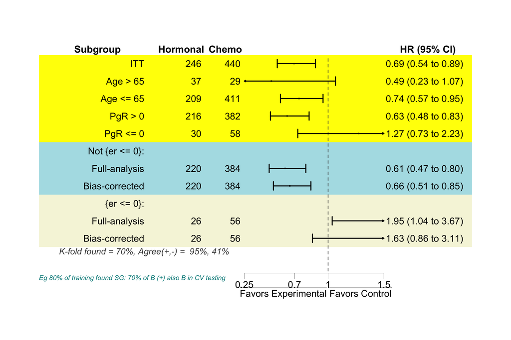

Subgroup forest plot including identified subgroups

```r
subgroups <- list(
  age_gt65     = list(subset_expr = "age > 65",  name = "Age > 65",  type = "reference"),
  age_le65     = list(subset_expr = "age <= 65", name = "Age <= 65", type = "reference"),
  pgr_positive = list(subset_expr = "pgr > 0",   name = "PgR > 0",   type = "reference"),
  pgr_negative = list(subset_expr = "pgr <= 0",  name = "PgR <= 0",  type = "reference")
)

my_theme <- create_forest_theme(base_size = 24,
                                 footnote_fontsize = 17,
                                 cv_fontsize = 22)

result <- plot_subgroup_results_forestplot(
  fs_results = list(
    fs.est   = fs,
    fs_bc    = fs_bc,
    fs_OOB   = NULL,
    fs_kfold = fs_kfold
  ),
  df_analysis      = df.analysis,
  subgroup_list    = subgroups,
  outcome.name     = outcome.name,
  event.name       = event.name,
  treat.name       = treat.name,
  E.name           = "Hormonal",
  C.name           = "Chemo",
  ci_column_spaces = 25,
  xlog             = TRUE,
  theme            = my_theme
)

render_forestplot(result)
```

## 8.2 KM Difference Plots: ITT and Subgroups

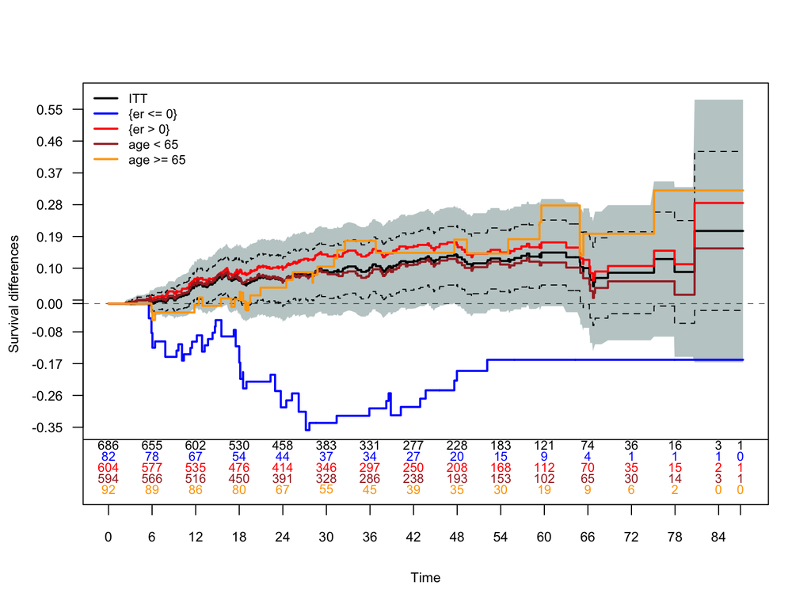

ITT (black) and subgroup KM differences with 95% confidence band.

```r
ref_sgs <- list(
  age_young = list(subset_expr = "age < 65",  color = "brown"),
  age_old   = list(subset_expr = "age >= 65", color = "orange")
)

plot_km_band_forestsearch(
  df            = df.analysis,
  fs.est        = fs,
  ref_subgroups = ref_sgs,
  outcome.name  = outcome.name,
  event.name    = event.name,
  treat.name    = treat.name,
  draws_band    = 20
)
```

# 9 Summary and Interpretation

## 9.1 Key Findings

```r
cat(strrep("=", 60), "\n")
cat("FORESTSEARCH ANALYSIS SUMMARY\n")
```

```
#> FORESTSEARCH ANALYSIS SUMMARY
```

```r
cat(strrep("=", 60), "\n\n")
cat("Dataset: GBSG (N =", nrow(df.analysis), ")\n")
```

```
#> Dataset: GBSG (N = 686 )
```

```r
cat("Outcome: Recurrence-free survival\n\n")
```

```
#> Outcome: Recurrence-free survival
```

```r
cat("ITT Analysis:\n")
```

```
#> ITT Analysis:
```

```r
cat("  HR (95% CI): 0.69 (0.54, 0.89)\n\n")
```

```
#>   HR (95% CI): 0.69 (0.54, 0.89)
```

```r
cat("Identified Subgroup (H):\n")
```

```
#> Identified Subgroup (H):
```

```r
cat("  Definition:", paste(fs$sg.harm, collapse = " & "), "\n")
```

```
#>   Definition: {er <= 0}
```

```r
cat("  Size:", sum(fs$df.est$treat.recommend == 0),
    sprintf("(%.1f%%)\n", 100 * mean(fs$df.est$treat.recommend == 0)))
```

```
#>   Size: 82 (12.0%)
```

```r
cat("  Unadjusted HR:",
    sprintf("%.2f", exp(fs$grp.consistency$out_sg$result$hr[1])), "\n")
```

[output not shown]

```r
cat("\nComplement Subgroup (Hc):\n")
```

```
#>
#> Complement Subgroup (Hc):
```

```r
cat("  Size:", sum(fs$df.est$treat.recommend == 1),
    sprintf("(%.1f%%)\n", 100 * mean(fs$df.est$treat.recommend == 1)))
```

```
#>   Size: 604 (88.0%)
```

## 9.2 Clinical Interpretation

The ForestSearch analysis identifies **estrogen receptor-negative (ER ≤ 0)** patients as a subgroup with potential lack of benefit from hormonal therapy.

**Biological plausibility**: Tamoxifen is a selective estrogen receptor modulator. Its efficacy depends on ER expression. The finding that ER-negative patients may not benefit is consistent with:

- Mechanistic understanding of tamoxifen action
- Meta-analyses showing no tamoxifen benefit in ER-negative breast cancer
- Clinical guidelines recommending tamoxifen primarily for ER-positive tumors

**Caveats**:

1. This is an **exploratory** analysis requiring independent validation.
2. The bias-corrected estimates have wider confidence intervals.
3. Cross-validation metrics should be evaluated for algorithm stability.
4. The procedure-level false-positive rate at the operational thresholds (c1 = 1.25, c2 = 1.00) is directly quantified in Section 10 below.

# 10 Appendix: Direct FPR Calibration at the Operational Thresholds

## 10.1 Motivation

The main analysis uses threshold pair (c1 = 1.25, c2 = 1.00) with `pconsistency.threshold = 0.9` and `stop_threshold = 0.95`. A natural question follows from any exploratory subgroup-identification analysis:

> Under the null hypothesis of *no treatment-by-subgroup interaction*, how often would ForestSearch spuriously identify **any** subgroup at these operational settings?

We answer this using the parametric GBSG DGM via `setup_gbsg_dgm(model = "null")` and the package’s supported simulation pipeline — `run_simulation_analysis()` → `collect_results()` → `format_oc_results()` — as configured in the León (2024) Table 1 reproduction documents. This yields a direct Monte Carlo FPR estimate plus the full operating-characteristics table (detection + classification) under H0 at the operational configuration used for subgroup identification.

## 10.2 Analysis setup

```r
# ── Parallel plan (same workers as main analysis) ─────────────────
plan(multisession, workers = n_workers)
cat("Workers:", n_workers, "\n")
```

```
#> Workers: 12
```

```r
# DGM and ForestSearch params are constructed in @sec-appendix-dgm-setup below.

# Note: helpers .wilson_ci(), .fpr_stage(), .sec_per_sim(), and %||% are
# hoisted to the main setup chunk at the top of the document so a knit-time
# self-test can run before any expensive simulation.
```

## 10.3 DGM-based FPR calibration

We use `setup_gbsg_dgm(model = "null")` as the null DGM — parameters calibrated to the GBSG AFT structure with treatment effect set to the null and no treatment-by-subgroup interaction. `simulate_from_dgm()` then generates the replicates inside `run_simulation_analysis()`.

### 10.3.1 DGM and ForestSearch parameter setup

```r
dgm_gbsg_null <- setup_gbsg_dgm(
  model   = "null",
  verbose = FALSE
)

# ForestSearch parameter list for run_simulation_analysis().  Retains
# the operational pcons / stop_threshold from the main GBSG analysis
# so the DGM-based FPR estimate is calibrated at the same operational
# setting used for subgroup identification.  Formatted in the style
# of reproduce_table1_m1.qmd's fs_cox list.
fs_params_runsim <- list(
  outcome.name           = "y_sim",
  event.name             = "event_sim",
  treat.name             = "treat_sim",
  id.name                = "id",
  hr.threshold           = c1_paper,
  hr.consistency         = c2_paper,
  pconsistency.threshold = pcons_val,
  stop_threshold         = stop_thresh_val,
  sg_focus               = "hr",
  max_subgroups_search   = max_sgs_search_val,
  use_twostage           = TRUE,
  fs.splits              = fs_splits_val,
  n.min                  = n_min_val,
  d0.min                 = d0_min_val,
  d1.min                 = d1_min_val,
  maxk                   = maxk_val,
  vi.grf.min             = -0.2,
  seedit                 = sim_seed_fpr,
  use_lasso              = TRUE,
  use_grf                = TRUE,        # FSlg: LASSO + GRF
  tune_grf               = FALSE,
  is.RCT                 = TRUE,
  details                = FALSE,
  quiet                  = TRUE,
  plot.sg                = FALSE,
  parallel_args          = list(
    plan = "sequential", workers = 1, show_message = FALSE
  )
)

# Cox formula (treatment-only, per León et al. 2024 Section 2)
cox_formula_adj_runsim <- survival::Surv(y_sim, event_sim) ~ treat_sim

# DGM-reference censoring rate: a single large-N draw from the DGM
# gives a low-variance Monte Carlo estimate of the theoretical
# censoring rate the DGM produces at (analysis_time_dgm, cens_adjust_dgm).
# At n = 10000, SE ~ 0.005 — precise enough to cross-check against the
# empirical rate averaged over the calibration replicates later on.
dgm_ref_draw <- simulate_from_dgm(
  dgm_gbsg_null,
  n             = 10000L,
  analysis_time = analysis_time_dgm,
  cens_adjust   = cens_adjust_dgm,
  seed          = sim_seed_fpr + 999L
)
prop_cens_ref <- 1 - mean(dgm_ref_draw$event_sim)

cat(sprintf("DGM null ready | N = %d | analysis_time = %d months | cens_adjust = %.3f\n",
            nrow(df.analysis), analysis_time_dgm, cens_adjust_dgm))
```

```
#> DGM null ready | N = 686 | analysis_time = 84 months | cens_adjust = 0.405
```

```r
cat(sprintf("DGM reference prop_cens: %.3f  (from n = 10000 single draw)\n",
            prop_cens_ref))
```

```
#> DGM reference prop_cens: 0.487  (from n = 10000 single draw)
```

### 10.3.2 Calibration batch

Primary FPR estimate from `nsims_tier1_fpr` = 50 null replicates.

```r
# Cache key: everything that changes the simulation output.
.cal_key <- list(
  nsims         = nsims_tier1_fpr,
  seed_base     = sim_seed_fpr + 2000L,
  fs_params     = fs_params_runsim,
  dgm_id        = list(model = "null", seed = 8316951L),
  n_sample      = nrow(df.analysis),
  analysis_time = analysis_time_dgm,
  cens_adjust   = cens_adjust_dgm,
  confounders   = confounders_dgm
)

.cal_cached <- .cache_compute(
  cache_file = "results_null.rds",
  key        = .cal_key,
  label      = sprintf("calibration batch (%d sims)", nsims_tier1_fpr),
  compute    = function() {
    t0 <- proc.time()[3]

    raw <- foreach(
      i = seq_len(nsims_tier1_fpr),
      .errorhandling = "pass",
      .options.future = list(packages = c("forestsearch"), seed = TRUE)
    ) %dofuture% {
      future::plan("sequential")

      r_fslg <- tryCatch(
        run_simulation_analysis(
          sim_id           = i,
          dgm              = dgm_gbsg_null,
          n_sample         = nrow(df.analysis),
          confounders_base = confounders_dgm,
          n_add_noise      = 0L,
          run_fs           = TRUE,
          run_fs_grf       = FALSE,
          run_grf          = FALSE,
          fs_params        = fs_params_runsim,
          cox_formula_adj  = cox_formula_adj_runsim,
          analysis_time    = analysis_time_dgm,
          cens_adjust      = cens_adjust_dgm,
          seed_base        = sim_seed_fpr + 2000L,
          verbose          = FALSE
        ),
        error = function(e) NULL
      )
      if (!is.null(r_fslg)) r_fslg$analysis <- "FSlg"

      data.table::rbindlist(
        Filter(Negate(is.null), list(r_fslg)),
        fill = TRUE
      )
    }

    plan("sequential")
    list(
      results = forestsearch::collect_results(raw, "H0 null"),
      elapsed = proc.time()[3] - t0
    )
  }
)

results_null       <- .cal_cached$results
timings$fpr_runsim <- .cal_cached$elapsed
n_failed_null      <- attr(results_null, "n_failed")
cat(sprintf("Calibration batch: %d sims (elapsed %.1f min, cache-aware)\n",
            nsims_tier1_fpr, timings$fpr_runsim / 60))
```

```
#> Calibration batch: 50 sims (elapsed 0.2 min, cache-aware)
```

```r
if (!is.null(n_failed_null) && n_failed_null > 0L)
  cat(sprintf("  *** %d of %d replicates failed ***\n",
              n_failed_null, nsims_tier1_fpr))
```

### 10.3.3 Verification batch

Independent null-simulation run on a **disjoint seed range** (`seed_base = sim_seed_fpr + 50000L`) that confirms the calibration FPR is reproducible on a fresh sample. Scale `nsims_verify_fpr` upward (e.g. 10,000–20,000) to achieve ±0.2–0.3 pp precision for a final production result. Set `nsims_verify_fpr = 0L` in the setup chunk to skip.

```r
if (nsims_verify_fpr > 0L) {
  .ver_key <- list(
    nsims         = nsims_verify_fpr,
    seed_base     = sim_seed_fpr + 50000L,
    fs_params     = fs_params_runsim,
    dgm_id        = list(model = "null", seed = 8316951L),
    n_sample      = nrow(df.analysis),
    analysis_time = analysis_time_dgm,
    cens_adjust   = cens_adjust_dgm,
    confounders   = confounders_dgm
  )

  .ver_cached <- .cache_compute(
    cache_file = "results_verify.rds",
    key        = .ver_key,
    label      = sprintf("verification batch (%d sims)", nsims_verify_fpr),
    compute    = function() {
      t0 <- proc.time()[3]

      # Reset worker pool to prevent memory accumulation from a prior
      # batch before running this one.
      plan(sequential); gc(verbose = FALSE); Sys.sleep(1)
      plan(multisession, workers = n_workers)

      raw <- foreach(
        i = seq_len(nsims_verify_fpr),
        .errorhandling = "pass",
        .options.future = list(packages = c("forestsearch"), seed = TRUE)
      ) %dofuture% {
        future::plan("sequential")

        r_fslg <- tryCatch(
          run_simulation_analysis(
            sim_id           = i,
            dgm              = dgm_gbsg_null,
            n_sample         = nrow(df.analysis),
            confounders_base = confounders_dgm,
            n_add_noise      = 0L,
            run_fs           = TRUE,
            run_fs_grf       = FALSE,
            run_grf          = FALSE,
            fs_params        = fs_params_runsim,
            cox_formula_adj  = cox_formula_adj_runsim,
            analysis_time    = analysis_time_dgm,
            cens_adjust      = cens_adjust_dgm,
            seed_base        = sim_seed_fpr + 50000L,
            verbose          = FALSE
          ),
          error = function(e) NULL
        )
        if (!is.null(r_fslg)) r_fslg$analysis <- "FSlg"

        data.table::rbindlist(
          Filter(Negate(is.null), list(r_fslg)),
          fill = TRUE
        )
      }

      plan("sequential")
      list(
        results = forestsearch::collect_results(raw, "H0 null (verify)"),
        elapsed = proc.time()[3] - t0
      )
    }
  )

  results_verify      <- .ver_cached$results
  timings$fpr_verify  <- .ver_cached$elapsed
  n_failed_verify     <- attr(results_verify, "n_failed")
  cat(sprintf("Verification batch: %d sims (elapsed %.1f min, cache-aware)\n",
              nsims_verify_fpr, timings$fpr_verify / 60))
  if (!is.null(n_failed_verify) && n_failed_verify > 0L)
    cat(sprintf("  *** %d of %d replicates failed ***\n",
                n_failed_verify, nsims_verify_fpr))
} else {
  results_verify <- NULL
  timings$fpr_verify <- 0
  message("Verification batch skipped (nsims_verify_fpr = 0L). ",
          "Set nsims_verify_fpr to a positive integer in the setup chunk to run.")
}
```

```
#> Verification batch: 50 sims (elapsed 0.2 min, cache-aware)
```

### 10.3.4 Theta-grid verification

Independent DGM simulations at θ†(H) ∈ 0.75, 0.9, 1.25, 1.5, 1.75, 2, 2.5, 3 test whether the corrected-FPR prediction from the calibration batch (estimated at θ = 1) can be transported to neighbouring values of the true harm-subgroup HR. For each θ we (1) calibrate `k_inter` to achieve `hr_H_true = θ`, (2) build an alternative DGM with `setup_gbsg_dgm(model = "alt", k_inter = ...)`, and (3) run `nsims_theta_verify` null replicates through `run_simulation_analysis()`. The resulting detection rates are overlaid as diamonds on the merged detection curve in Section 10.5. The θ = 1 diamond there comes from the verification batch above (no alternative DGM needed — θ = 1 is the null). Set `nsims_theta_verify = 0L` in the setup chunk to skip this block.

```r
if (nsims_theta_verify > 0L && length(theta_grid_verify) > 0L) {
  .theta_key <- list(
    theta_grid    = theta_grid_verify,
    nsims         = nsims_theta_verify,
    fs_params     = fs_params_runsim,
    n_sample      = nrow(df.analysis),
    analysis_time = analysis_time_dgm,
    cens_adjust   = cens_adjust_dgm,
    confounders   = confounders_dgm,
    seed_offsets  = sim_seed_fpr + 80000L + seq_along(theta_grid_verify),
    sim_seeds     = sim_seed_fpr + 100000L + 1000L * seq_along(theta_grid_verify)
  )

  .theta_cached <- .cache_compute(
    cache_file = "theta_verify.rds",
    key        = .theta_key,
    label      = sprintf("theta-grid verification (%d θ × %d sims)",
                         length(theta_grid_verify), nsims_theta_verify),
    compute    = function() {
      t0 <- proc.time()[3]

      # ── Step 1: Calibrate k_inter and build one alt DGM per θ ──
      # Sequential computation — done BEFORE activating multisession
      # so workers don't sit idle during ~30–60 s of k_inter calibration.
      plan(sequential)

      alt_dgms <- vector("list", length(theta_grid_verify))
      names(alt_dgms) <- sprintf("theta_%.2f", theta_grid_verify)
      for (j in seq_along(theta_grid_verify)) {
        th   <- theta_grid_verify[j]
        kj   <- calibrate_k_inter(
          target_hr_harm = th,
          k_treat        = 1.0,
          seed           = sim_seed_fpr + 80000L + j,
          verbose        = FALSE
        )
        alt_dgms[[j]] <- setup_gbsg_dgm(
          model   = "alt",
          k_treat = 1.0,
          k_inter = kj,
          seed    = sim_seed_fpr + 80000L + j,
          verbose = FALSE
        )
        cat(sprintf("  θ=%.2f calibrated: k_inter=%.4f | hr_H_true=%.3f\n",
                    th, kj, alt_dgms[[j]]$hr_H_true))
      }

      # ── Step 2: Run sims per θ, resetting workers before each ──
      theta_rows <- vector("list", length(theta_grid_verify))
      for (j in seq_along(theta_grid_verify)) {
        th  <- theta_grid_verify[j]
        dgj <- alt_dgms[[j]]
        seed_offset_j <- 100000L + 1000L * j

        plan(sequential); gc(verbose = FALSE); Sys.sleep(1)
        plan(multisession, workers = n_workers)

        raw_j <- foreach(
          i = seq_len(nsims_theta_verify),
          .errorhandling = "pass",
          .options.future = list(packages = c("forestsearch"), seed = TRUE)
        ) %dofuture% {
          future::plan("sequential")

          r <- tryCatch(
            run_simulation_analysis(
              sim_id           = i,
              dgm              = dgj,
              n_sample         = nrow(df.analysis),
              confounders_base = confounders_dgm,
              n_add_noise      = 0L,
              run_fs           = TRUE,
              run_fs_grf       = FALSE,
              run_grf          = FALSE,
              fs_params        = fs_params_runsim,
              cox_formula_adj  = cox_formula_adj_runsim,
              analysis_time    = analysis_time_dgm,
              cens_adjust      = cens_adjust_dgm,
              seed_base        = sim_seed_fpr + seed_offset_j,
              verbose          = FALSE
            ),
            error = function(e) NULL
          )
          if (!is.null(r)) r$analysis <- "FSlg"
          data.table::rbindlist(
            Filter(Negate(is.null), list(r)), fill = TRUE)
        }

        res_j <- forestsearch::collect_results(
          raw_j, sprintf("theta=%.2f", th))
        rj    <- res_j[res_j$analysis == "FSlg", ]
        ndet  <- sum(rj$any.H == 1L, na.rm = TRUE)
        nrep  <- nrow(rj)
        ci    <- .wilson_ci(ndet, nrep)

        theta_rows[[j]] <- data.table(
          theta      = th,
          nsims      = nrep,
          detections = ndet,
          fpr        = ndet / nrep,
          ci_lo      = ci[1],
          ci_hi      = ci[2]
        )
        cat(sprintf("  θ=%.2f: detection %d/%d = %.1f%% [%.1f%%, %.1f%%]\n",
                    th, ndet, nrep, 100 * ndet / nrep,
                    100 * ci[1], 100 * ci[2]))
      }

      plan("sequential")
      list(
        df      = data.table::rbindlist(theta_rows),
        elapsed = proc.time()[3] - t0
      )
    }
  )

  theta_verify_df          <- .theta_cached$df
  timings$fpr_theta_verify <- .theta_cached$elapsed

  cat(sprintf("\nTheta-grid verification: %d θ values × %d sims (elapsed %.1f min, cache-aware)\n",
              length(theta_grid_verify), nsims_theta_verify,
              timings$fpr_theta_verify / 60))
} else {
  theta_verify_df <- NULL
  timings$fpr_theta_verify <- 0
  message("Theta-grid verification skipped (nsims_theta_verify = 0L).")
}
```

```
#>   θ=0.75 calibrated: k_inter=0.2029 | hr_H_true=0.750
```

```
#>   θ=0.90 calibrated: k_inter=0.4408 | hr_H_true=0.900
```

```
#>   θ=1.25 calibrated: k_inter=0.8416 | hr_H_true=1.250
```

```
#>   θ=1.50 calibrated: k_inter=1.1125 | hr_H_true=1.500
```

```
#>   θ=1.75 calibrated: k_inter=1.2866 | hr_H_true=1.750
```

```
#>   θ=2.00 calibrated: k_inter=1.4884 | hr_H_true=2.000
```

```
#>   θ=2.50 calibrated: k_inter=1.7320 | hr_H_true=2.500
```

```
#>   θ=3.00 calibrated: k_inter=1.9714 | hr_H_true=3.000
#>   θ=0.75: detection 1/50 = 2.0% [0.4%, 10.5%]
#>   θ=0.90: detection 3/50 = 6.0% [2.1%, 16.2%]
#>   θ=1.25: detection 10/50 = 20.0% [11.2%, 33.0%]
#>   θ=1.50: detection 24/50 = 48.0% [34.8%, 61.5%]
#>   θ=1.75: detection 29/50 = 58.0% [44.2%, 70.6%]
#>   θ=2.00: detection 47/50 = 94.0% [83.8%, 97.9%]
#>   θ=2.50: detection 47/50 = 94.0% [83.8%, 97.9%]
#>   θ=3.00: detection 48/50 = 96.0% [86.5%, 98.9%]
```

```
#>
#> Theta-grid verification: 8 θ values × 50 sims (elapsed 2.2 min, cache-aware)
```

## 10.4 Results

### 10.4.1 Operating characteristics (detection + classification)

```r
# Publication-ready OC table via format_oc_results().  Under H0,
# any.H is the FPR; sens / ppv are null by construction (the
# unconditional averaging convention used in the reproduction docs).
format_oc_results(
  results_null,
  analyses = "FSlg",
  metrics  = c("detection", "classification"),
  digits   = 3,
  title    = "GBSG Null — DGM-based FPR Calibration",
  subtitle = sprintf(
    "N = %d, %d sims, θ†(ITT) ≈ %.2f",
    nrow(df.analysis), nsims_tier1_fpr, dgm_gbsg_null$hr_causal
  ),
  subgroup_notation = "harm"
)
```

GBSG Null — DGM-based FPR Calibration

N = 686, 50 sims, θ†(ITT) ≈ 0.72

| Method | Sims | Found | Classification Sen | Classification Spec | Classification PPV | Classification NPV |
| --- | --- | --- | --- | --- | --- | --- |
| FSlg | 50 | 0.020 | - | 0.998 | 0.000 | 1.000 |

### 10.4.2 Asymptotic approximation

The León et al. (2024) asymptotic approximation (equation 3) gives the per-subgroup detection probability P1 at the operational threshold pair, using effective information d_eff derived from the minimum subgroup size `n.min` and the observed censoring proportion. This is a **model-based** reference value computed independently of the simulation — the implied L_eff below quantifies how many effectively independent candidate subgroups the procedure is evaluating, obtained by matching this P1 against the simulated FPR.

We first cross-check the censoring rate from two independent sources:

- **DGM reference**: one large n = 10,000 draw from `dgm_gbsg_null` via `simulate_from_dgm()` (computed in the setup chunk). This is a low-variance Monte Carlo estimate of the DGM’s theoretical censoring rate at the current (`analysis_time_dgm`, `cens_adjust_dgm`) settings — independent of any ForestSearch call.
- **Empirical**: the mean of `p.cens` across the calibration batch replicates (each at n = 686).

Agreement between the two (difference < 0.02 = 2 pp) confirms that the DGM’s censoring model is internally consistent at both sample sizes. We use the empirical rate for downstream d_eff / P1 calculations since it reflects the exact `n` and seed handling used in the calibration batch.

```r
# Empirical censoring proportion from the calibration batch.
# run_simulation_analysis() records p.cens = 1 - mean(event_sim) for
# each replicate, so we average across replicates to get the rate
# the DGM actually produces at n = nrow(df.analysis) with the
# current (analysis_time_dgm, cens_adjust_dgm) settings.
prop_cens_emp <- mean(results_null$p.cens, na.rm = TRUE)

# Cross-check: compare the empirical rate (averaged over the
# calibration batch at n = 686) against the DGM-reference rate
# (single n = 10000 draw computed in the setup chunk).  They should
# agree up to Monte Carlo noise — disagreement would indicate a
# sample-size-dependent censoring effect worth investigating.
prop_cens_diff <- abs(prop_cens_emp - prop_cens_ref)

cat("Censoring rate check:\n")
```

```
#> Censoring rate check:
```

```r
cat(sprintf("  DGM reference:  %.3f  (n = 10000 single draw)\n",
            prop_cens_ref))
```

```
#>   DGM reference:  0.487  (n = 10000 single draw)
```

```r
cat(sprintf("  Empirical:      %.3f  (averaged over %d replicates at n = %d)\n",
            prop_cens_emp,
            sum(!is.na(results_null$p.cens)),
            nrow(df.analysis)))
```

```
#>   Empirical:      0.498  (averaged over 50 replicates at n = 686)
```

```r
cat(sprintf("  |difference|:   %.3f  (expected < 0.02 for agreement)\n\n",
            prop_cens_diff))
```

```
#>   |difference|:   0.011  (expected < 0.02 for agreement)
```

```r
# Per-subgroup asymptotic P1 at (c1, c2, d_eff) under H0.
# Use the empirical censoring rate since it reflects the n, analysis_time,
# and cens_adjust used in the calibration batch directly.
d_eff_est <- forestsearch::d_eff_survival(n_min_val, prop_cens_emp)
P1_est    <- tryCatch(
  forestsearch::compute_detection_probability_glm(
    theta = 1.0, d_eff = d_eff_est,
    c1 = c1_paper, c2 = c2_paper,
    effect_scale = "ratio", method = "monte_carlo"),
  error = function(e) NA_real_)

cat("Asymptotic approximation (León 2024, eq. 3):\n")
```

```
#> Asymptotic approximation (León 2024, eq. 3):
```

```r
cat(sprintf("  d_eff       = %.1f  (n.min = %d, prop_cens = %.3f)\n",
            d_eff_est, n_min_val, prop_cens_emp))
```

```
#>   d_eff       = 30.1  (n.min = 60, prop_cens = 0.498)
```

```r
cat(sprintf("  P1(theta=1) = %.1f%%  (per-subgroup asymptotic FPR)\n",
            100 * P1_est))
```

```
#>   P1(theta=1) = 19.7%  (per-subgroup asymptotic FPR)
```

### 10.4.3 Summary

```r
# Note: .wilson_ci() is defined in the fpr-setup chunk (hoisted for
# use across theta-grid verification and this summary chunk).

# ── Step 1: Calibration batch — estimate L_eff from the data ─────
rn_cal   <- results_null[results_null$analysis == "FSlg", ]
n_cal    <- nrow(rn_cal)
ndet_cal <- sum(rn_cal$any.H == 1L, na.rm = TRUE)
fpr_cal  <- ndet_cal / n_cal
ci_cal   <- .wilson_ci(ndet_cal, n_cal)

# This is the ESTIMATED parameter carried forward to the Corrected
# FPR prediction.  L_eff_cal is the pair-specific effective
# multiplicity derived by matching the calibration-batch simulated
# FPR against the asymptotic P1.
L_eff_cal <- if (!is.na(fpr_cal) && !is.na(P1_est) &&
                 fpr_cal > 0 && fpr_cal < 1 &&
                 P1_est > 0 && P1_est < 1)
  log(1 - fpr_cal) / log(1 - P1_est) else NA_real_

# Corrected FPR prediction:  1 − (1 − P1)^L_eff_cal
# This equals fpr_cal for the Calibration row (tautology by
# construction) and serves as the PREDICTION for the Verification
# row.  Both rows show the same value; the verification row's Sim
# FPR is the out-of-sample target.
fpr_corr_pred <- if (!is.na(P1_est) && !is.na(L_eff_cal))
  1 - (1 - P1_est)^L_eff_cal else NA_real_

# ── Step 2: Verification batch (optional) ─────────────────────────
if (!is.null(results_verify)) {
  rn_ver   <- results_verify[results_verify$analysis == "FSlg", ]
  n_ver    <- nrow(rn_ver)
  ndet_ver <- sum(rn_ver$any.H == 1L, na.rm = TRUE)
  fpr_ver  <- ndet_ver / n_ver
  ci_ver   <- .wilson_ci(ndet_ver, n_ver)
} else {
  n_ver <- NA_integer_; fpr_ver <- NA_real_
  ci_ver <- c(NA_real_, NA_real_)
}

# ── Step 3: Build the two-row (or one-row) summary table ──────────
fmt_pct <- function(x) {
  if (is.na(x)) "—" else sprintf("%.1f%%", 100 * x)
}
fmt_ci <- function(lo, hi) {
  if (any(is.na(c(lo, hi)))) "—"
  else sprintf("[%.1f%%, %.1f%%]", 100 * lo, 100 * hi)
}

row_cal <- data.table(
  Batch            = sprintf("Calibration (%d sims)", n_cal),
  Sims             = n_cal,
  `Sim FPR`        = fmt_pct(fpr_cal),
  `95% CI`         = fmt_ci(ci_cal[1], ci_cal[2]),
  `Implied L_eff`  = if (!is.na(L_eff_cal)) sprintf("%.3f", L_eff_cal) else "—",
  `Corrected FPR`  = fmt_pct(fpr_corr_pred),
  fpr_num          = fpr_cal
)

if (!is.null(results_verify)) {
  row_ver <- data.table(
    Batch            = sprintf("Verification (%d sims)", n_ver),
    Sims             = n_ver,
    `Sim FPR`        = fmt_pct(fpr_ver),
    `95% CI`         = fmt_ci(ci_ver[1], ci_ver[2]),
    `Implied L_eff`  = "— (carried forward)",
    `Corrected FPR`  = fmt_pct(fpr_corr_pred),
    fpr_num          = fpr_ver
  )
  summary_tbl <- rbind(row_cal, row_ver)
} else {
  summary_tbl <- row_cal
}

# Out-of-sample diagnostic: is fpr_ver within the corrected FPR's
# CI?  Report the percentage-point gap in the source note.
ver_gap_pp <- if (!is.null(results_verify) &&
                  !is.na(fpr_ver) && !is.na(fpr_corr_pred)) {
  100 * abs(fpr_ver - fpr_corr_pred)
} else {
  NA_real_
}

# ── Step 4: Extract best estimates for downstream plotting ────────
# Use verification when available (higher precision); otherwise
# calibration.  L_eff_implied used by the detection curve plot is
# always the calibration estimate (L_eff_cal).
if (!is.null(results_verify) && !is.na(fpr_ver)) {
  fpr_hat <- fpr_ver; fpr_ci <- ci_ver; n_reps <- n_ver
} else {
  fpr_hat <- fpr_cal; fpr_ci <- ci_cal; n_reps <- n_cal
}
L_eff_implied <- L_eff_cal  # always the calibration estimate

# ── Step 5: Render the table ──────────────────────────────────────
src_note <- paste(
  "Null replicates simulated from setup_gbsg_dgm(model = 'null').",
  "FPR = mean(any.H) across replicates (FSlg: LASSO + GRF screening).",
  "Calibration batch: seed_base = sim_seed_fpr + 2000L.",
  "Verification batch: seed_base = sim_seed_fpr + 50000L (disjoint seed range).",
  "Implied L_eff = log(1 − Sim FPR) / log(1 − P1) from the Calibration batch",
  "— this is the pair-specific effective multiplicity, used as the estimated",
  "parameter for the Corrected FPR prediction.",
  "Corrected FPR = 1 − (1 − P1)^L_eff_implied.  For the Calibration row this",
  "equals Sim FPR by construction (tautology).  For the Verification row it",
  "is the PREDICTION carried forward from the Calibration batch;",
  "agreement with the Verification Sim FPR confirms the correction works out",
  "of sample."
)
if (!is.na(ver_gap_pp)) {
  src_note <- paste(
    src_note,
    sprintf("Out-of-sample gap: |Sim FPR (verify) − Corrected FPR (predicted)| = %.1f pp.",
            ver_gap_pp)
  )
}

gt(summary_tbl) |>
  tab_header(
    title    = sprintf(
      "GBSG: DGM-based FPR Calibration | c1 = %.2f, c2 = %.2f | pcons = %.2f, stop = %.2f",
      c1_paper, c2_paper, pcons_val, stop_thresh_val),
    subtitle = sprintf(
      "N = %d | n.min = %d | P1(asymp) = %s",
      nrow(df.analysis), n_min_val,
      if (!is.na(P1_est)) sprintf("%.1f%%", 100 * P1_est) else "—")
  ) |>
  cols_hide(columns = fpr_num) |>
  tab_source_note(src_note)
```

DGM-based FPR calibration at the GBSG operational thresholds. The Calibration batch estimates L_eff from the simulated FPR and the asymptotic P1; that L_eff is then carried forward to predict the Corrected FPR. The Verification batch (independent seeds) provides an out-of-sample test: its Sim FPR should fall close to the Corrected FPR predicted from the Calibration row.

GBSG: DGM-based FPR Calibration | c1 = 1.25, c2 = 1.00 | pcons = 0.90, stop = 0.95

N = 686 | n.min = 60 | P1(asymp) = 19.7%

| Batch | Sims | Sim FPR | 95% CI | Implied L_eff | Corrected FPR |
| --- | --- | --- | --- | --- | --- |
| Calibration (50 sims) | 50 | 2.0% | [0.4%, 10.5%] | 0.092 | 2.0% |
| Verification (50 sims) | 50 | 10.0% | [4.3%, 21.4%] | — (carried forward) | 2.0% |

Null replicates simulated from setup_gbsg_dgm(model = 'null'). FPR = mean(any.H) across replicates (FSlg: LASSO + GRF screening). Calibration batch: seed_base = sim_seed_fpr + 2000L. Verification batch: seed_base = sim_seed_fpr + 50000L (disjoint seed range). Implied L_eff = log(1 − Sim FPR) / log(1 − P1) from the Calibration batch — this is the pair-specific effective multiplicity, used as the estimated parameter for the Corrected FPR prediction. Corrected FPR = 1 − (1 − P1)^L_eff_implied. For the Calibration row this equals Sim FPR by construction (tautology). For the Verification row it is the PREDICTION carried forward from the Calibration batch; agreement with the Verification Sim FPR confirms the correction works out of sample. Out-of-sample gap: |Sim FPR (verify) − Corrected FPR (predicted)| = 8.0 pp.

## 10.5 Detection curves at the operational threshold pair

The detection curve below combines two views of the detection probability as a function of the true harm-subgroup HR θ†(H):

- For **θ ≤ 1.25 (null region)**: the corrected prediction `1 − (1 − P1(θ))^L_eff_cal`, using the pair-specific effective multiplicity estimated from the calibration batch at θ = 1.
- For **θ ≥ 1.25 (alt region)**: the uncorrected per-subgroup asymptotic P1(θ) from the León (2024) equation-3 approximation, which empirically tracks power well when the subgroup effect is strong enough to be reliably detected.

**Both predictions are shown at θ = 1.25**, so the reader can compare the corrected and uncorrected values directly against the verification diamond at that θ — it is plausible that the uncorrected P1 is already the more accurate predictor at the boundary.

The choice of 1.25 as the cut-off between the two regions is a **working hypothesis** — we do not claim any procedural or theoretical significance for that particular value. Verification simulations at θ ∈ {0.75, 0.9, 1, 1.25, 1.5, 1.75, 2, 2.5, 3} (diamonds with Wilson 95% CIs) empirically test the merged curve. Agreement within CIs across the null region supports the “transportability” of `L_eff_cal`; systematic departure would indicate the correction should be re-estimated θ-by-θ rather than carried forward from θ = 1.

```r
# Local wrapper (to be exported from forestsearch in a future release).
# Builds a MERGED detection curve: corrected prediction for theta <= theta_cut,
# uncorrected per-subgroup P1 for theta >= theta_cut.  Both segments INCLUDE
# the boundary so the reader can compare two predictions (corrected and
# uncorrected) directly against the verification diamond at theta = theta_cut.
# Verification diamonds are overlaid from an optional data.table with columns
# theta / fpr / ci_lo / ci_hi.
plot_fpr_calibration <- function(cal_result,
                                  theta_seq      = seq(0.5, 3.0, by = 0.05),
                                  theta_cut      = 1.25,
                                  theta_verify   = NULL,
                                  fpr_target     = NULL,
                                  label          = NULL,
                                  effect_label   = "Effect ratio (theta)") {
  stopifnot(inherits(cal_result, "fpr_calibration"))

  c1       <- cal_result$c1
  c2       <- cal_result$c2
  d_eff    <- cal_result$d_eff
  L_eff    <- cal_result$L_eff_implied
  fpr_hat  <- cal_result$fpr
  ci_lo    <- cal_result$fpr_ci[1]
  ci_hi    <- cal_result$fpr_ci[2]
  N        <- cal_result$N
  nsims    <- cal_result$nsims

  # ── Build the two raw curves ─────────────────────────────────────
  p1_vec <- sapply(theta_seq, function(th)
    tryCatch(
      compute_detection_probability_glm(
        theta = th, d_eff = d_eff, c1 = c1, c2 = c2,
        effect_scale = "ratio", method = "monte_carlo"),
      error = function(e) NA_real_))

  p_corr_vec <- if (!is.na(L_eff)) {
    1 - (1 - p1_vec)^L_eff
  } else {
    rep(NA_real_, length(theta_seq))
  }

  # ── Merge: corrected for theta <= cut, uncorrected for theta >= cut ─────
  # Both segments INCLUDE theta_cut so the reader sees two endpoints at
  # the merge boundary: the corrected prediction (red, ending at cut)
  # and the uncorrected P1 (grey, starting at cut).  This lets the
  # reader compare both model predictions directly against the
  # verification diamond at theta = theta_cut.
  null_idx <- theta_seq <= theta_cut
  alt_idx  <- theta_seq >= theta_cut

  curve_dt <- rbind(
    data.frame(theta = theta_seq[null_idx],
               prob  = p_corr_vec[null_idx],
               curve = sprintf("Corrected prediction (θ ≤ %.2f)", theta_cut)),
    data.frame(theta = theta_seq[alt_idx],
               prob  = p1_vec[alt_idx],
               curve = sprintf("Per-subgroup P1 (θ ≥ %.2f)", theta_cut))
  )

  # ── Verification diamonds ────────────────────────────────────────
  # Start with the calibration-batch θ = 1 result (always present),
  # then append any theta_verify data.table supplied by the caller.
  sim_pts <- data.frame(
    theta = 1, prob = fpr_hat, ci_lo = ci_lo, ci_hi = ci_hi
  )
  if (!is.null(theta_verify) && nrow(theta_verify) > 0L) {
    sim_pts <- rbind(
      sim_pts,
      data.frame(
        theta = theta_verify$theta,
        prob  = theta_verify$fpr,
        ci_lo = theta_verify$ci_lo,
        ci_hi = theta_verify$ci_hi
      )
    )
  }

  sub_txt <- sprintf(
    "c1=%.2f, c2=%.2f | d_eff=%.1f | L_eff(calibration)=%.3f | N=%d | calibration sims=%d",
    c1, c2, d_eff,
    if (!is.na(L_eff)) L_eff else 0,
    N, nsims)
  if (!is.null(label)) sub_txt <- paste0(label, " | ", sub_txt)

  p <- ggplot(curve_dt, aes(x = theta, y = prob,
                             colour = curve, linetype = curve)) +
    geom_line(linewidth = 0.9, na.rm = TRUE) +
    geom_vline(xintercept = 1, linetype = "dotted",
               colour = "grey60", linewidth = 0.4) +
    geom_vline(xintercept = theta_cut, linetype = "dashed",
               colour = "grey40", linewidth = 0.5) +
    annotate("text",
             x = theta_cut, y = 0.02,
             label = sprintf("θ = %.2f (merge boundary)", theta_cut),
             hjust = -0.05, vjust = 0, size = 3, colour = "grey40") +
    geom_point(data = sim_pts, aes(x = theta, y = prob),
               colour = "steelblue", size = 3.5, shape = 18,
               inherit.aes = FALSE) +
    geom_errorbar(data = sim_pts,
                  aes(x = theta, ymin = ci_lo, ymax = ci_hi),
                  colour = "steelblue", width = 0.04, linewidth = 0.7,
                  inherit.aes = FALSE) +
    scale_colour_manual(values = setNames(
      c("firebrick", "grey50"),
      c(sprintf("Corrected prediction (θ ≤ %.2f)", theta_cut),
        sprintf("Per-subgroup P1 (θ ≥ %.2f)", theta_cut))
    )) +
    scale_linetype_manual(values = setNames(
      c("solid", "dashed"),
      c(sprintf("Corrected prediction (θ ≤ %.2f)", theta_cut),
        sprintf("Per-subgroup P1 (θ ≥ %.2f)", theta_cut))
    )) +
    scale_y_continuous(labels = scales::percent, limits = c(0, NA)) +
    labs(x        = effect_label,
         y        = "Detection probability",
         title    = sprintf("Merged Detection Curve: c1 = %.2f, c2 = %.2f",
                            c1, c2),
         subtitle = sub_txt,
         colour   = NULL, linetype = NULL) +
    theme_minimal(base_size = 12) +
    theme(legend.position = "top",
          plot.title    = element_text(face = "bold"),
          plot.subtitle = element_text(size = 9, colour = "grey40"))

  if (!is.null(fpr_target)) {
    p <- p +
      geom_hline(yintercept = fpr_target, linetype = "dashed",
                 colour = "darkgreen", linewidth = 0.5) +
      annotate("text",
               x = min(theta_seq) + 0.05, y = fpr_target + 0.01,
               label = sprintf("FPR target = %.0f%%", 100 * fpr_target),
               hjust = 0, size = 3, colour = "darkgreen")
  }
  p
}
```

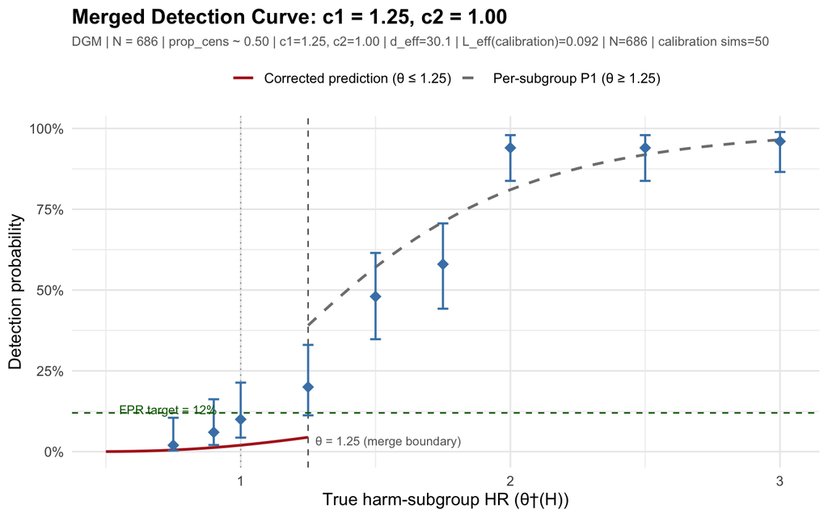

```r
# Synthesize an fpr_calibration-shaped object from the run_simulation_analysis
# results so the plot wrapper can render the detection curve without change.
cal_for_plot <- structure(
  list(
    fpr           = fpr_hat,
    fpr_ci        = fpr_ci,
    nsims         = n_reps,
    P1            = P1_est,
    d_eff         = d_eff_est,
    L_eff_implied = L_eff_implied,
    c1            = c1_paper,
    c2            = c2_paper,
    N             = nrow(df.analysis)
  ),
  class = "fpr_calibration"
)

plot_fpr_calibration(
  cal_for_plot,
  theta_cut    = theta_merge_cut,
  theta_verify = theta_verify_df,
  fpr_target   = fpr_target_surv,
  effect_label = "True harm-subgroup HR (θ†(H))",
  label        = sprintf("DGM | N = %d | prop_cens ~ %.2f",
                          nrow(df.analysis), prop_cens_emp)
)
```

## 10.6 Interpretation

**Reading the result.** The summary table in Section 10.4.3 follows an **estimate-then-predict** structure at the main-analysis operating point — threshold pair (1.25, 1.00) with `pconsistency.threshold = 0.9` and `stop_threshold = 0.95`:

- **Calibration row** (50 sims, seed offset +2000) — supplies the **estimated parameter**. The Sim FPR from this batch is matched against the asymptotic P1 from Section 10.4.2 to derive the implied L_eff: `L_eff = log(1 − Sim FPR) / log(1 − P1)`. The Corrected FPR in this row (`1 − (1 − P1)^L_eff`) equals the Sim FPR by construction — it’s a tautological check that the round-trip is consistent.
- **Verification row** (50 sims, seed offset +50000, disjoint seed range) — provides an **out-of-sample test**. Its Sim FPR is an independent simulation of the same quantity, while its Corrected FPR is the **prediction carried forward** from the Calibration row’s L_eff (same numeric value in both rows). Agreement between the Verification Sim FPR and the Corrected FPR prediction confirms the correction generalises beyond the calibration sample.

Set `nsims_verify_fpr = 0L` to skip the verification; scale up (e.g. 10,000–20,000) for ±0.2–0.3 pp precision on a final production result. Wilson 95% CI widths scale as $1/\sqrt{N_{\text{sims}}}$.

**Operating characteristics table.** Section 10.4.1 shows the full `format_oc_results()` output from the calibration batch. The `any.H` entry equals the calibration-batch Sim FPR; sens / ppv are null by construction (the unconditional averaging convention from the paper — the true harm subgroup is empty under H0).

**Asymptotic P1 and implied L_eff.** Section 10.4.2 reports P1 and d_eff from the León (2024) equation-3 approximation — a model-based per-subgroup reference computed independently of the simulation. The implied L_eff is the pair-specific effective multiplicity that reconciles the simulated FPR with the asymptotic P1, quantifying how many effectively independent candidate subgroups the procedure is evaluating after LASSO + GRF + two-stage screening with `maxk = 2`. For survival with events-based filters (`d0.min`, `d1.min`), L_eff is typically close to or below 1 when the filters prune the candidate pool tightly; values well above 1 indicate the candidate pool is larger than a single test.

**Merged detection curve and transportability (Section 10.5).** The detection curve in Section 10.5 combines two regimes: the **corrected prediction** `1 − (1 − P1(θ))^L_eff_cal` for θ ≤ 1.25 (null region), and the **uncorrected per-subgroup P1(θ)** for θ ≥ 1.25 (alt region). Both predictions are shown at the boundary θ = 1.25, so the reader can compare them directly against the verification diamond at that θ — the corrected and uncorrected curves typically differ by a non-trivial gap at the boundary, and which one sits closer to the empirical diamond indicates the more accurate predictor in that neighbourhood. The value 1.25 itself is a working-hypothesis guess for where the corrected prediction stops being the right thing to show; no procedural or theoretical significance is claimed for it. Independent verification simulations at θ†(H) ∈ {0.75, 0.9, 1, 1.25, 1.5, 1.75, 2, 2.5, 3} (diamonds with Wilson 95% CIs) test the transportability of `L_eff_cal` across the null region. If those diamonds fall on the corrected curve within CI width, the assumption that a single `L_eff` estimated at θ = 1 transports across θ ∈ [min(theta_grid_verify), 1.25] is empirically supported. Systematic departure would indicate the correction should be re-estimated θ-by-θ rather than carried forward — or that the merge cut-off should be moved earlier, if the uncorrected P1 is already the more accurate predictor below 1.25.

**Interpreting the identified ER ≤ 0 subgroup.** The FPR figure above is the procedure-level Type-I error rate: the probability that ForestSearch identifies *any* subgroup under H0 at these operational settings. It is not subgroup-specific and should be interpreted as a property of the analysis procedure rather than of the specific subgroup found. The biological plausibility of the tamoxifen / ER-status mechanism supports the finding, and the calibrated FPR quantifies the Type-I error of the identification procedure to complement the clinical evidence.

## 10.7 (c₁, c₂) sensitivity sweep

The grid used here is:

$$\text{c}_1 \in \{1, 1.25, 1.4\}
\;\times\;
\text{c}_2 \in \{0.9, 1\}
\quad\text{subject to } \text{c}_2 < \text{c}_1,$$

which yields the 5 valid pairs enumerated in the table below. The 50-sim tier-1 batches are cached per pair under `_cache_gbsg_sweep/` so adding a new pair on a later knit only pays the cost of the new pair.

```r
# Build the grid of (c1, c2) pairs subject to c2 < c1.
sweep_grid <- do.call(rbind, lapply(c1_sweep, function(c1_) {
  do.call(rbind, lapply(c2_sweep, function(c2_) {
    data.frame(c1 = c1_, c2 = c2_)
  }))
}))
sweep_grid <- sweep_grid[sweep_grid$c2 < sweep_grid$c1, ]
rownames(sweep_grid) <- NULL

# Flag the reference pair (1.25, 1.00) so it can be rendered emphasized
# on the overlay plot.
sweep_grid$is_ref <- (sweep_grid$c1 == c1_paper) &
                      (sweep_grid$c2 == c2_paper)

# Cache directory, parallel to the main appendix cache
sweep_cache_dir <- "_cache_gbsg_sweep"
if (cache_sweep && !dir.exists(sweep_cache_dir))
  dir.create(sweep_cache_dir, showWarnings = FALSE)

cat(sprintf("(c1, c2) sensitivity grid: %d pairs\n", nrow(sweep_grid)))
```

```
#> (c1, c2) sensitivity grid: 5 pairs
```

```r
print(sweep_grid)
```

```
#>     c1  c2 is_ref
#> 1 1.00 0.9  FALSE
#> 2 1.25 0.9  FALSE
#> 3 1.25 1.0   TRUE
#> 4 1.40 0.9  FALSE
#> 5 1.40 1.0  FALSE
```

### 10.7.1 Sweep execution

For each pair, run `nsims_sweep` null replicates using `fs_params_runsim` with `hr.threshold` and `hr.consistency` overridden to (c₁, c₂). Results cache per-pair under `_cache_gbsg_sweep/sweep_c1_<c1>_c2_<c2>.rds`.

```r
# ── Helper: run a single tier-1 batch at a given (c1, c2) ────────
.run_sweep_pair <- function(c1_val, c2_val) {
  fs_params_pair <- modifyList(fs_params_runsim, list(
    hr.threshold   = c1_val,
    hr.consistency = c2_val
  ))

  plan(sequential); gc(verbose = FALSE); Sys.sleep(1)
  plan(multisession, workers = n_workers)

  t0 <- proc.time()[3]
  raw <- foreach(
    i = seq_len(nsims_sweep),
    .errorhandling = "pass",
    .options.future = list(packages = c("forestsearch"), seed = TRUE)
  ) %dofuture% {
    future::plan("sequential")
    r <- tryCatch(
      run_simulation_analysis(
        sim_id           = i,
        dgm              = dgm_gbsg_null,
        n_sample         = nrow(df.analysis),
        confounders_base = confounders_dgm,
        n_add_noise      = 0L,
        run_fs           = TRUE,
        run_fs_grf       = FALSE,
        run_grf          = FALSE,
        fs_params        = fs_params_pair,
        cox_formula_adj  = cox_formula_adj_runsim,
        analysis_time    = analysis_time_dgm,
        cens_adjust      = cens_adjust_dgm,
        seed_base        = sweep_seed_base + round(1000 * c1_val) +
                           round(100  * c2_val),
        verbose          = FALSE
      ),
      error = function(e) NULL
    )
    if (!is.null(r)) r$analysis <- "FSlg"
    data.table::rbindlist(Filter(Negate(is.null), list(r)), fill = TRUE)
  }
  plan("sequential")
  elapsed <- proc.time()[3] - t0

  res    <- forestsearch::collect_results(raw, sprintf("sweep c1=%.2f c2=%.2f",
                                                       c1_val, c2_val))
  rn     <- res[res$analysis == "FSlg", ]
  n_rep  <- nrow(rn)
  ndet   <- sum(rn$any.H == 1L, na.rm = TRUE)
  fpr    <- ndet / n_rep
  ci     <- .wilson_ci(ndet, n_rep)

  # Asymptotic P1 and L_eff at this (c1, c2).  Note: d_eff_survival()
  # takes (n_sg, prop_cens) — the conservative choice is n_sg = n.min
  # (subgroup-size floor), matching the reference-pair asymptotic block.
  d_eff  <- forestsearch::d_eff_survival(
    n_sg      = fs_params_pair$n.min,
    prop_cens = mean(rn$p.cens, na.rm = TRUE))
  P1     <- forestsearch::compute_detection_probability_glm(
    theta = 1, d_eff = d_eff, c1 = c1_val, c2 = c2_val,
    effect_scale = "ratio", method = "monte_carlo")
  L_eff  <- if (!is.na(P1) && P1 > 0 && P1 < 1 && !is.na(fpr) && fpr < 1)
    log(1 - fpr) / log(1 - P1) else NA_real_

  list(
    c1 = c1_val, c2 = c2_val, fpr = fpr, ci_lo = ci[1], ci_hi = ci[2],
    n_reps = n_rep, d_eff = d_eff, P1 = P1, L_eff = L_eff,
    elapsed = elapsed
  )
}

# ── Cache wrapper: one .rds per pair ─────────────────────────────
.sweep_cached_pair <- function(c1_val, c2_val) {
  if (!cache_sweep) return(.run_sweep_pair(c1_val, c2_val))

  cache_file <- sprintf("sweep_c1_%.2f_c2_%.2f.rds", c1_val, c2_val)
  key <- list(
    c1            = c1_val,
    c2            = c2_val,
    nsims         = nsims_sweep,
    seed_base     = sweep_seed_base,
    fs_params     = fs_params_runsim,
    dgm_id        = list(model = "null", seed = 8316951L),
    n_sample      = nrow(df.analysis),
    analysis_time = analysis_time_dgm,
    cens_adjust   = cens_adjust_dgm,
    confounders   = confounders_dgm
  )
  path <- file.path(sweep_cache_dir, cache_file)

  if (!cache_refresh && file.exists(path)) {
    cached <- readRDS(path)
    if (identical(cached$key, key)) {
      message(sprintf("[sweep cache HIT ] c1=%.2f c2=%.2f",
                      c1_val, c2_val))
      return(cached$value)
    }
    message(sprintf("[sweep cache MISS] c1=%.2f c2=%.2f: key changed",
                    c1_val, c2_val))
  } else {
    message(sprintf("[sweep cache MISS] c1=%.2f c2=%.2f: %s",
                    c1_val, c2_val,
                    if (cache_refresh) "cache_refresh = TRUE"
                    else "no cache file"))
  }
  val <- .run_sweep_pair(c1_val, c2_val)
  saveRDS(list(key = key, value = val), path)
  message(sprintf("[sweep cache SAVE] c1=%.2f c2=%.2f", c1_val, c2_val))
  val
}

# ── Run all pairs ─────────────────────────────────────────────────
sweep_results <- vector("list", nrow(sweep_grid))
for (k in seq_len(nrow(sweep_grid))) {
  sweep_results[[k]] <- .sweep_cached_pair(
    sweep_grid$c1[k], sweep_grid$c2[k])
}
timings$fpr_sweep <- sum(vapply(sweep_results,
                                function(x) x$elapsed %||% 0, numeric(1)))

# Summary table
sweep_df <- do.call(rbind, lapply(sweep_results, function(r) {
  data.frame(
    c1 = r$c1, c2 = r$c2,
    nsims = r$n_reps,
    fpr = r$fpr, ci_lo = r$ci_lo, ci_hi = r$ci_hi,
    P1 = r$P1, L_eff = r$L_eff
  )
}))
sweep_df$is_ref <- sweep_grid$is_ref

cat(sprintf("\nSweep completed: %d pairs × %d sims, elapsed %.1f min\n",
            nrow(sweep_grid), nsims_sweep, timings$fpr_sweep / 60))
```

```
#>
#> Sweep completed: 5 pairs × 50 sims, elapsed 1.1 min
```

### 10.7.2 Sweep summary table

```r
gt(sweep_df) |>
  fmt_number(columns = c(c1, c2), decimals = 2) |>
  fmt_percent(columns = c(fpr, ci_lo, ci_hi, P1), decimals = 1) |>
  fmt_number(columns = L_eff, decimals = 3) |>
  fmt_integer(columns = nsims) |>
  cols_merge(columns = c(ci_lo, ci_hi), pattern = "[{1}, {2}]") |>
  cols_hide(columns = is_ref) |>
  cols_label(
    c1    = "c1",
    c2    = "c2",
    nsims = "Sims",
    fpr   = "Sim FPR",
    ci_lo = "95% CI",
    P1    = "P1(asymp)",
    L_eff = "Implied L_eff"
  ) |>
  tab_header(
    title = sprintf("(c1, c2) sensitivity sweep | N = %d | %d sims per pair",
                    nrow(df.analysis), nsims_sweep),
    subtitle = sprintf(
      "Reference pair (%.2f, %.2f) shown in bold",
      c1_paper, c2_paper)
  ) |>
  tab_style(
    style = cell_text(weight = "bold"),
    locations = cells_body(rows = is_ref)
  ) |>
  tab_style(
    style = cell_fill(color = "#F5F5F5"),
    locations = cells_body(rows = is_ref)
  ) |>
  tab_source_note(paste(
    "Simulated from the same null DGM (setup_gbsg_dgm(model = 'null'))",
    "used for the reference calibration.  Sim FPR = mean(any.H) at this",
    "(c1, c2); P1(asymp) = compute_detection_probability_glm(theta = 1, ...);",
    "Implied L_eff = log(1 − Sim FPR) / log(1 − P1).  Seeds are",
    "pair-specific and disjoint from the reference tier-1, verification,",
    "and theta-grid batches."
  ))
```

(c1, c2) sensitivity sweep | N = 686 | 50 sims per pair

Reference pair (1.25, 1.00) shown in bold

| c1 | c2 | Sims | Sim FPR | 95% CI | P1(asymp) | Implied L_eff |
| --- | --- | --- | --- | --- | --- | --- |
| 1.00 | 0.90 | 50 | 20.0% | [11.2%, 33.0%] | 32.6% | 0.565 |
| 1.25 | 0.90 | 50 | 16.0% | [8.3%, 28.5%] | 22.4% | 0.687 |
| 1.25 | 1.00 | 50 | 8.0% | [3.2%, 18.8%] | 19.7% | 0.381 |
| 1.40 | 0.90 | 50 | 6.0% | [2.1%, 16.2%] | 15.9% | 0.357 |
| 1.40 | 1.00 | 50 | 6.0% | [2.1%, 16.2%] | 14.6% | 0.393 |

Simulated from the same null DGM (setup_gbsg_dgm(model = 'null')) used for the reference calibration. Sim FPR = mean(any.H) at this (c1, c2); P1(asymp) = compute_detection_probability_glm(theta = 1, ...); Implied L_eff = log(1 − Sim FPR) / log(1 − P1). Seeds are pair-specific and disjoint from the reference tier-1, verification, and theta-grid batches.

### 10.7.3 Overlay of merged detection curves

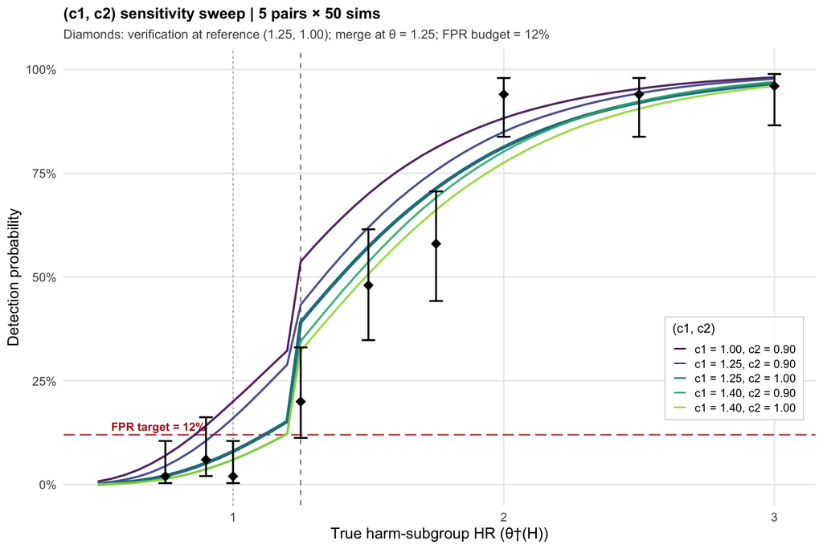

```r
theta_seq_sweep <- seq(0.5, 3.0, by = 0.05)

# Build per-pair curve data
sweep_curve_df <- do.call(rbind, lapply(sweep_results, function(r) {
  # Uncorrected P1 curve at this (c1, c2)
  p1 <- sapply(theta_seq_sweep, function(th)
    tryCatch(
      compute_detection_probability_glm(
        theta = th, d_eff = r$d_eff, c1 = r$c1, c2 = r$c2,
        effect_scale = "ratio", method = "monte_carlo"),
      error = function(e) NA_real_))
  # Corrected prediction
  p_corr <- if (!is.na(r$L_eff)) 1 - (1 - p1)^r$L_eff
            else rep(NA_real_, length(theta_seq_sweep))

  # Merge: corrected for θ ≤ cut, uncorrected for θ ≥ cut (same split
  # used for the reference figure — makes curves visually comparable)
  null_idx <- theta_seq_sweep <= theta_merge_cut
  alt_idx  <- theta_seq_sweep >= theta_merge_cut
  merged <- numeric(length(theta_seq_sweep))
  merged[null_idx] <- p_corr[null_idx]
  merged[alt_idx]  <- p1[alt_idx]

  data.frame(
    theta    = theta_seq_sweep,
    prob     = merged,
    pair     = sprintf("c1 = %.2f, c2 = %.2f", r$c1, r$c2),
    is_ref   = (r$c1 == c1_paper) & (r$c2 == c2_paper)
  )
}))

# Verification diamonds (reference pair only).  Include θ = 1 from the
# reference calibration and any theta_grid_verify points.
ref_diamonds <- data.frame(
  theta = 1, prob = fpr_cal, ci_lo = ci_cal[1], ci_hi = ci_cal[2]
)
if (!is.null(theta_verify_df) && nrow(theta_verify_df) > 0L) {
  ref_diamonds <- rbind(
    ref_diamonds,
    data.frame(theta = theta_verify_df$theta,
               prob  = theta_verify_df$fpr,
               ci_lo = theta_verify_df$ci_lo,
               ci_hi = theta_verify_df$ci_hi)
  )
}

# Per-pair linewidth and alpha: reference pair emphasized
sweep_curve_df$lwd   <- ifelse(sweep_curve_df$is_ref, 1.3, 0.8)
sweep_curve_df$alpha <- ifelse(sweep_curve_df$is_ref, 1.0, 0.85)

ggplot(sweep_curve_df, aes(x = theta, y = prob,
                           colour = pair, group = pair)) +
  # FPR target demarcation line (horizontal) — the analyst's
  # operational budget for procedure-level Type-I error.  Drawn more
  # prominently than the θ = 1 / θ = theta_merge_cut reference lines
  # because it directly indicates which (c1, c2) pairs fall within the
  # target budget vs exceed it.
  geom_hline(yintercept = fpr_target_surv, linetype = "longdash",
             colour = "firebrick", linewidth = 0.6, alpha = 0.8) +
  annotate("text",
           x = 0.55, y = fpr_target_surv,
           label = sprintf("FPR target = %.0f%%", 100 * fpr_target_surv),
           hjust = 0, vjust = -0.5,
           size = 3.2, colour = "firebrick", fontface = "bold") +
  geom_vline(xintercept = 1, linetype = "dotted",
             colour = "grey60", linewidth = 0.4) +
  geom_vline(xintercept = theta_merge_cut, linetype = "dashed",
             colour = "grey40", linewidth = 0.4) +
  geom_line(aes(linewidth = lwd, alpha = alpha), na.rm = TRUE) +
  geom_errorbar(data = ref_diamonds,
                aes(x = theta, ymin = ci_lo, ymax = ci_hi),
                colour = "black", width = 0.05, linewidth = 0.7,
                inherit.aes = FALSE) +
  geom_point(data = ref_diamonds,
             aes(x = theta, y = prob),
             colour = "black", size = 3.5, shape = 18,
             inherit.aes = FALSE) +
  scale_colour_viridis_d(option = "viridis", end = 0.85) +
  scale_linewidth_identity() +
  scale_alpha_identity() +
  scale_y_continuous(labels = scales::percent_format(accuracy = 1),
                     limits = c(0, 1)) +
  labs(
    x      = "True harm-subgroup HR (θ†(H))",
    y      = "Detection probability",
    colour = "(c1, c2)",
    title  = sprintf("(c1, c2) sensitivity sweep | %d pairs × %d sims",
                     nrow(sweep_grid), nsims_sweep),
    subtitle = sprintf(
      "Diamonds: verification at reference (%.2f, %.2f); merge at θ = %.2f; FPR budget = %.0f%%",
      c1_paper, c2_paper, theta_merge_cut, 100 * fpr_target_surv)
  ) +
  theme(
    legend.position        = "inside",                       # ggplot2 >= 3.5.0 idiom
    legend.position.inside = c(0.80, 0.30),                  # right-middle band of panel
    legend.justification    = c(0, 0.5),                      # left-middle anchor of legend
    legend.background       = element_rect(fill = scales::alpha("white", 0.85),
                                           colour = "grey80", linewidth = 0.3),
    legend.key              = element_rect(fill = NA, colour = NA),
    legend.key.size         = unit(0.8, "lines"),
    legend.title            = element_text(size = 10),
    legend.text             = element_text(size = 9),
    legend.margin           = margin(4, 6, 4, 6),
    plot.title              = element_text(size = 12, face = "bold"),
    plot.subtitle           = element_text(size = 10, colour = "grey30"),
    panel.grid.minor        = element_blank()
  )
```

### 10.7.4 Interpretation of the sweep

**FPR side (left of θ = 1).** At θ = 1 each curve’s y-value is that pair’s simulated FPR under H0, and the range of FPRs across the grid shows how sensitive the procedure-level Type-I error is to operational threshold choice. The reference pair (1.25, 1.00) is one point in this range; tighter thresholds (larger c₁ and/or c₂) push FPR down, looser thresholds push it up. The red dashed horizontal line at 12% marks the analyst’s FPR budget — any pair whose curve lies below this line at θ = 1 is operating within the target Type-I error rate.

**Reading the tradeoff.** A pair that sits uniformly above another is both more powerful (higher TPR in the alt region) and less conservative (higher FPR in the null region) — that pair trades Type-I error for Type-II error. A pair that dominates another on both axes (rare but possible when the grid is coarse) is strictly better. Ordinarily the curves reveal a Pareto frontier, and the analyst’s job is to choose the point on that frontier consistent with the trial’s error-rate budget.

# 11 Computational Timing

```r
# Helpers (%||%, .fpr_stage, .sec_per_sim) are defined in the main setup
# chunk so they can be QC-tested before any expensive simulation.
timings$total <- (proc.time() - t_vignette_start)["elapsed"]

# FPR appendix sub-components — individual stages plus rolled-up total.
# Each stage may be 0 (skipped via nsims_*_fpr = 0L) or NA (not run at
# all).  Show NA for skipped stages in the table so the reader can tell
# a skip from a fast run.
fpr_tier1_sec  <- .fpr_stage(timings$fpr_runsim)        # calibration batch
fpr_verify_sec <- .fpr_stage(timings$fpr_verify)        # verification batch
fpr_theta_sec  <- .fpr_stage(timings$fpr_theta_verify)  # theta-grid verification
fpr_sweep_sec  <- .fpr_stage(timings$fpr_sweep)         # (c1, c2) sensitivity sweep

timings$fpr_total <- sum(c(fpr_tier1_sec, fpr_verify_sec, fpr_theta_sec,
                           fpr_sweep_sec),
                         na.rm = TRUE)

n_theta_total <- if (!is.null(theta_verify_df))
  sum(theta_verify_df$nsims, na.rm = TRUE) else NA_integer_

n_sweep_total <- if (exists("sweep_df") && !is.null(sweep_df))
  sum(sweep_df$nsims, na.rm = TRUE) else NA_integer_

timing_df <- data.frame(
  Analysis = c("GRF",
               "ForestSearch",
               "Bootstrap",
               "kfold CV",
               "OOB CV",
               "FPR tier 1 (calibration batch)",
               "FPR verification batch",
               "FPR theta-grid verification",
               "FPR (c1, c2) sensitivity sweep",
               "FPR calibration — total (appendix)",
               "Total"),
  Seconds = as.numeric(c(
    timings$grf          %||% NA_real_,
    timings$forestsearch %||% NA_real_,
    timings$bootstrap    %||% NA_real_,
    timings$kfold        %||% NA_real_,
    timings$oob          %||% NA_real_,
    fpr_tier1_sec,
    fpr_verify_sec,
    fpr_theta_sec,
    fpr_sweep_sec,
    if (timings$fpr_total > 0) timings$fpr_total else NA_real_,
    timings$total        %||% NA_real_
  )),
  Sims = c(
    NA_integer_, NA_integer_,
    NB_boot %||% NA_integer_,
    Ksims_cv %||% NA_integer_,
    Ksims_cv %||% NA_integer_,
    nsims_tier1_fpr %||% NA_integer_,
    nsims_verify_fpr %||% NA_integer_,
    n_theta_total,
    n_sweep_total,
    NA_integer_,
    NA_integer_
  )
)
timing_df$Minutes     <- timing_df$Seconds / 60
timing_df$sec_per_sim <- mapply(.sec_per_sim, timing_df$Seconds, timing_df$Sims)

gt(timing_df) |>
  tab_header(title = "Computational Timing") |>
  fmt_number(columns = c(Seconds, Minutes), decimals = 1,
             rows = !is.na(Seconds)) |>
  fmt_number(columns = sec_per_sim, decimals = 2,
             rows = !is.na(sec_per_sim)) |>
  fmt_integer(columns = Sims, rows = !is.na(Sims)) |>
  sub_missing(missing_text = "—") |>
  cols_label(
    Analysis    = "Component",
    Seconds     = "Time (sec)",
    Minutes     = "Time (min)",
    Sims        = "Sims",
    sec_per_sim = "sec / sim"
  ) |>
  tab_style(
    style = cell_text(weight = "bold"),
    locations = cells_body(rows = Analysis %in% c(
      "FPR calibration — total (appendix)", "Total"))
  ) |>
  tab_style(
    style = cell_fill(color = "#F5F5F5"),
    locations = cells_body(rows = Analysis %in% c(
      "FPR tier 1 (calibration batch)",
      "FPR verification batch",
      "FPR theta-grid verification",
      "FPR (c1, c2) sensitivity sweep"))
  ) |>
  tab_source_note(paste(
    "FPR calibration stages are shaded grey; their sum appears as the",
    "bold 'FPR calibration — total (appendix)' row.",
    "sec/sim divides elapsed time by the simulation count for the",
    "appendix stages and by NB_boot / Ksims_cv for bootstrap / CV.",
    "Dashes indicate skipped or non-simulation components.",
    "When cached stages are loaded from .rds (cache HIT), the elapsed",
    "time shown is from the ORIGINAL run, not the current knit."))
```

Computational Timing

| Component | Time (sec) | Sims | Time (min) | sec / sim |
| --- | --- | --- | --- | --- |
| GRF | 0.2 | — | 0.0 | — |
| ForestSearch | 3.5 | — | 0.1 | — |
| Bootstrap | 88.4 | 200 | 1.5 | 0.44 |
| kfold CV | 26.7 | 5 | 0.4 | 5.34 |
| OOB CV | 4.4 | 5 | 0.1 | 0.87 |
| FPR tier 1 (calibration batch) | 11.8 | 50 | 0.2 | 0.24 |
| FPR verification batch | 13.9 | 50 | 0.2 | 0.28 |
| FPR theta-grid verification | 132.3 | 400 | 2.2 | 0.33 |
| FPR (c1, c2) sensitivity sweep | 66.4 | 250 | 1.1 | 0.27 |
| FPR calibration — total (appendix) | 224.4 | — | 3.7 | — |
| Total | 362.9 | — | 6.0 | — |

FPR calibration stages are shaded grey; their sum appears as the bold 'FPR calibration — total (appendix)' row. sec/sim divides elapsed time by the simulation count for the appendix stages and by NB_boot / Ksims_cv for bootstrap / CV. Dashes indicate skipped or non-simulation components. When cached stages are loaded from .rds (cache HIT), the elapsed time shown is from the ORIGINAL run, not the current knit.

# 12 References

León LF, Jemielita T, Guo Z, Marceau West R, Anderson KM (2024). “Exploratory subgroup identification in the heterogeneous Cox model: A relatively simple procedure.” *Statistics in Medicine*. DOI: 10.1002/sim.10163

# 13 Session Info

```r
plan(sequential)
```